# Análisis del régimen de precipitación en Cantabria: tendencias, rachas e índices de estacionalidad

Bloque 2 del TFM *Estudio estadístico de variaciones meteorológicas y oceánicas en Cantabria*”

Sara Lanza Sarabia

# Sección 1 - Carga de librerías y datos

## Bloque de librerías

Cargamos las librerías necesarias para el análisis de precipitación:

- `dplyr` y `tidyr`: manipulación y transformación de dataframes
- `ggplot2`: generación de gráficos
- `readr`: lectura eficiente de archivos CSV
- `lubridate`: manejo y conversión de componentes de fechas
- `zoo`: medias móviles centradas (`rollmean`) sobre series temporales
- `patchwork`: composición de múltiples gráficos en paneles
- `trend`: test de Mann-Kendall estándar (`mk.test`), estimador de Sen (`sens.slope`) con intervalos de confianza al 95%, y test de Pettitt
- `modifiedmk`: test de Mann-Kendall con corrección TFPW para series con autocorrelación significativa de primer orden (`tfpwmk`)
- `purrr`: programación funcional (map_dfr para iterar sobre meses y estaciones)
- `tibble`: creación y manipulación de tibbles
- `kableExtra`: formato enriquecido de tablas HTML en documentos R Markdown

```r
library(dplyr)       # Manipulación de datos
library(ggplot2)     # Visualización de datos
library(readr)       # Importación de datos
library(lubridate)   # Manejo de fechas
library(zoo)         # Medias móviles
library(patchwork)   # Combinación de múltiples gráficos en una sola figura
library(trend)       # Pruebas de tendencia (Mann-Kendall, Sen's Slope, entre otras)
library(modifiedmk)  # Mann-Kendall modificado
library(purrr)       # Programación funcional
library(tibble)      # Creación de tibbles
library(kableExtra)  # Formato de tablas
```

## Bloque de carga de datos

Cargamos los datos diarios de las dos estaciones meteorológicas empleadas en el análisis. datos_tama corresponde a Tama (1972-2025, interior de Cantabria a 893 m) y datos_santander a Santander (1961-2025, litoral cantábrico), resultado de la fusión de los registros del Instituto Oceanográfico (1961-1977) con los datos de la AEMET (1978-2025). Ambos contienen la columna prec con la precipitación diaria en mm y las variables de fecha anio, mes y dia.

```r
# Cargar los datos diarios de las estaciones meteorológicas
datos_tama <- read_csv("datosDiariosMeteo_tama_1972_to_2025.csv")
datos_santander <- read_csv("datosDiariosMeteo_santander_1961_to_2025.csv")
```

# Sección 1: Limpieza de los datos de precipitación

`limpiar_base()` realiza la limpieza estructural común a todos los análisis: elimina las columnas innecesarias para el análisis de precipitación y convierte las variables de fecha `anio`, `mes` y `dia` a formato numérico. Esta función actúa como base de `limpiar_precipitacion()`, que la llama internamente antes de aplicar el tratamiento específico de la columna `prec`.

```r
# Función base para la limpieza de los datos meteorológicos
limpiar_base <- function(df) {
  # Eliminar las columnas que no se utilizarán en el análisis
  df <- df[, !(names(df) %in% c("nombre","indicativo", "provincia", "fecha", "altitud", "horatmin", "horatmax",
                                "hrMedia", "hrMax", "velmedia", "horaHrMax", "hrMin", "horaHrMin", "racha",
                                "horaracha", "dir"))]

  # Convertir las variables de fecha a formato numérico
  df$anio <- as.numeric(df$anio)
  df$mes <- as.numeric(df$mes)
  df$dia <- as.numeric(df$dia)

  return(df)
}
```

`limpiar_precipitacion()` realiza el tratamiento completo de la columna `prec` en cinco etapas:

1. Limpieza inicial de cadenas especiales — espacios en blanco, valores *Ip* y *Tr* reemplazados por 0.01 mm, comas decimales convertidas a puntos, y registro previo de los días *Acum* en la columna `es_acum`
2. Identificación de bloques consecutivos de *Acum* mediante `rle()`
3. Tratamiento de los bloques acumulados según su longitud:
   - Si el bloque tiene como máximo `max_reparto` días (por defecto 7) y existe un valor válido en el día inmediatamente posterior, la precipitación total se reparte uniformemente entre todos los días del bloque y el día de cierre
   - Si el bloque es más largo o no hay valor posterior, todos esos días se marcan como NA
4. Eliminación de las columnas auxiliares
5. Creación de las columnas derivadas *lluvia* (`TRUE` si `prec` > 0.1 mm) y *seco* (`TRUE` si `prec` <= 0.1 mm).

```r
# Función para la limpieza y tratamiento de la precipitación
limpiar_precipitacion <- function(df, max_reparto = 7) {

  df <- limpiar_base(df)

  # =========================
  # 1. LIMPIEZA INICIAL
  # =========================

  df$prec <- trimws(df$prec)

  # Identificar los registros con precipitación acumulada antes de convertirlos en NA
  df$es_acum <- df$prec == "Acum"

  # Convertir valores vacíos y "NA" en valores perdidos
  df$prec[df$prec %in% c("", "NA")] <- NA

  # Sustituir "Acum" por NA para facilitar su tratamiento posterior
  df$prec[df$prec == "Acum"] <- NA

  # Reemplazar códigos de precipitación por valores numéricos
  df$prec <- gsub("Ip", "0.01", df$prec)
  df$prec <- gsub("Tr", "0.01", df$prec)
  df$prec <- gsub(",", ".", df$prec)

  # Convertir la precipitación a formato numérico
  df$prec <- as.numeric(df$prec)

  # Ordenar cronológicamente los registros
  df <- df %>% arrange(anio, mes, dia)

  # =========================
  # 2. IDENTIFICACIÓN DE BLOQUES ACUMULADOS
  # =========================

  rle_acum <- rle(df$es_acum) # Identificar bloques consecutivos de "Acum"
  bloque_id <- rep(seq_along(rle_acum$lengths), times = rle_acum$lengths) # Asignar un identificador a cada bloque

  df$bloque_acum <- bloque_id
  df$long_bloque <- rep(rle_acum$lengths, times = rle_acum$lengths)

  # =========================
  # 3. TRATAMIENTO DE LOS VALORES ACUMULADOS
  # =========================

  prec_new <- df$prec # Copia del vector de precipitación para aplicar las correcciones

  i <- 1
  n <- nrow(df)

  while (i <= n) {

    if (!is.na(df$es_acum[i]) && df$es_acum[i]) {

      # Identificar el bloque completo de valores acumulados
      bloque <- df$bloque_acum[i]
      idx <- which(df$bloque_acum == bloque)

      # Obtener el primer valor válido tras el bloque
      next_val <- NA

      if (max(idx) < n) {
        next_val <- df$prec[max(idx) + 1]
      }

      len_bloque <- length(idx)

      # =========================
      # CASO A: BLOQUE CORTO
      # =========================

      # Repartir la precipitación acumulada entre los días del bloque y el día siguiente
      if (len_bloque <= max_reparto && !is.na(next_val)) {

        total <- next_val
        reparto <- rep(total / (len_bloque + 1), len_bloque + 1)
        prec_new[c(idx, max(idx) + 1)] <- reparto

      # Si el bloque es demasiado largo o no existe un valor posterior,
      # la precipitación se mantiene como NA
      } else {

        # =========================
        # CASO B: BLOQUE LARGO
        # =========================

        prec_new[c(idx, max(idx) + 1)] <- NA
      }

      i <- max(idx) + 1
    } else {
      i <- i + 1
    }
  }

  # Actualizar la columna de precipitación con los valores corregidos
  df$prec <- prec_new

  # =========================
  # 4. LIMPIEZA FINAL
  # =========================

  # Eliminar las variables auxiliares creadas durante el tratamiento
  df <- df %>%
    select(-bloque_acum, -long_bloque)

  # =========================
  # 5. VARIABLES DERIVADAS
  # =========================

  # Crear variables lógicas de días lluviosos y secos (umbral: 0,1 mm)
  df$lluvia <- ifelse(is.na(df$prec), NA, df$prec > 0.1)
  df$seco <- ifelse(is.na(df$prec), NA, df$prec <= 0.1)

  return(df)
}
```

## Bloque de aplicación de limpieza

Aplicamos `limpiar_precipitacion()` a ambos datasets. A continuación generamos dos versiones del dataset de Tama con propósitos distintos:

- `datos_tama_con_NA` conserva los registros con NA en prec y se usa en los análisis que requieren la serie temporal completa (rachas de sequía, análisis de continuidad)
- `datos_tama_sin_NA` elimina esas filas y se emplea en los análisis cuantitativos que necesitan valores numéricos en todos los registros (precipitación total, intensidad, extremos, comparación entre periodos).

Para Santander se usa directamente `datos_santander_limpios` en ambos roles.

```r
# Aplicar la limpieza de la precipitación a cada conjunto de datos
datos_tama_limpios <- limpiar_precipitacion(datos_tama)
datos_santander_limpios <- limpiar_precipitacion(datos_santander)

# Mantener los valores NA para los análisis de continuidad (p. ej., rachas de sequía)
datos_tama_con_NA <- datos_tama_limpios

# Eliminar los valores NA para los análisis basados en precipitaciones observadas
datos_tama_sin_NA <- datos_tama_limpios %>% filter(!is.na(prec))
```

## Bloque de control de calidad inicial

El bloque de control de calidad tabula los años de cada estación con **menos de 330 días con dato** (umbral equivalente al ~90.4% de cobertura anual), documentando explícitamente qué años podrían verse excluidos de los análisis estadísticos de tendencia en secciones posteriores.

```r
# Identificar años con menos de 330 días con datos en cada estación
datos_santander_limpios %>%
  group_by(anio) %>%
  summarise(dias_con_dato = n(), .groups = "drop") %>%
  filter(dias_con_dato < 330) %>%
  knitr::kable(
    col.names = c("Año", "Nº de días con datos"),
    caption = "Años con menos de 330 observaciones en Santander."
  ) %>%
  kableExtra::kable_styling(
    bootstrap_options = c("striped", "hover", "condensed"),
    full_width = FALSE,
    position = "center"
  )
```

Años con menos de 330 observaciones en Santander.

| Año | Nº de días con datos |
| --- | --- |
| 1975 | 221 |
| 1977 | 122 |

```r
datos_tama_sin_NA %>%
  group_by(anio) %>%
  summarise(dias_con_dato = n(), .groups = "drop") %>%
  filter(dias_con_dato < 330) %>%
  knitr::kable(
    col.names = c("Año", "Nº de días con datos"),
    caption = "Años con menos de 330 observaciones en Tama."
  ) %>%
  kableExtra::kable_styling(
    bootstrap_options = c("striped", "hover", "condensed"),
    full_width = FALSE,
    position = "center"
  )
```

Años con menos de 330 observaciones en Tama.

| Año | Nº de días con datos |
| --- | --- |
| 1985 | 325 |
| 2006 | 153 |
| 2007 | 200 |
| 2010 | 243 |
| 2011 | 209 |

# Sección 2 - Imputación de valores faltantes (NA)

## 2.1 - Detección de bloques de datos faltantes

`detectar_bloques_na()` es una herramienta auxiliar de diagnóstico que no forma parte del pipeline analítico principal. Usa `rle()` para identificar bloques consecutivos de NA en una variable (por defecto `prec`), asignando a cada fila un identificador de bloque (`bloque_id`) y la longitud de ese bloque (`bloque_longitud`). Se aplica al dataset de Tama con NA para caracterizar los datos faltantes antes de decidir la estrategia de imputación.

```r
# Función para identificar bloques consecutivos de valores NA en una variable
detectar_bloques_na <- function(df, variable = "prec") {

  # Identificar bloques consecutivos de valores NA
  es_na <- is.na(df[[variable]])
  rle_na <- rle(es_na)

  # Asignar un identificador y su longitud a cada bloque
  bloque_id <- rep(seq_along(rle_na$lengths), times = rle_na$lengths)
  bloque_longitud <- rep(rle_na$lengths, times = rle_na$lengths)

  # Incorporar la información al conjunto de datos
  df$es_na <- es_na
  df$bloque_id <- bloque_id
  df$bloque_longitud <- bloque_longitud

  return(df)
}

# Identificar los bloques de valores NA en la serie de precipitación de Tama
bloques_NA_tama <- detectar_bloques_na(datos_tama_con_NA)
```

La primera tabla resultante lista todos los bloques individuales de NA ordenados de mayor a menor duración, mostrando fecha de inicio y fin de cada uno. La segunda tabla resume cuántos bloques hay de cada longitud, lo que permite evaluar si los NA son predominantemente aislados (susceptibles de imputación) o forman bloques extensos que deben tratarse como irrecuperables.

```r
# Resumir los bloques de valores NA identificados en la serie de Tama
bloques_NA_tama %>%
  filter(es_na) %>%
  group_by(bloque_id) %>%
  summarise(
    inicio = sprintf("%02d-%02d-%04d",
                     min(dia[which.min(anio + mes/12 + dia/365)]),
                     min(mes[which.min(anio + mes/12 + dia/365)]),
                     min(anio[which.min(anio + mes/12 + dia/365)])),
    fin = sprintf("%02d-%02d-%04d",
                  max(dia[which.max(anio + mes/12 + dia/365)]),
                  max(mes[which.max(anio + mes/12 + dia/365)]),
                  max(anio[which.max(anio + mes/12 + dia/365)])),
    longitud = n(),
    .groups = "drop"
  ) %>%
  arrange(desc(longitud)) %>%
  knitr::kable(
    col.names = c("Bloque ID", "Inicio", "Fin", "Longitud (días)"),
    caption = "Bloques de datos faltantes (NA) detectados en la estación Tama."
  ) %>%
  kableExtra::kable_styling(
    bootstrap_options = c("striped", "hover", "condensed"),
    full_width = FALSE,
    position = "center"
  )
```

Bloques de datos faltantes (NA) detectados en la estación Tama.

| Bloque ID | Inicio | Fin | Longitud (días) |
| --- | --- | --- | --- |
| 8 | 01-09-2010 | 31-05-2011 | 273 |
| 4 | 01-10-1991 | 31-10-1991 | 31 |
| 14 | 03-02-2013 | 12-02-2013 | 10 |
| 2 | 05-05-1985 | 13-05-1985 | 9 |
| 10 | 04-06-2011 | 06-06-2011 | 3 |
| 12 | 08-06-2011 | 09-06-2011 | 2 |
| 16 | 03-11-2014 | 04-11-2014 | 2 |
| 6 | 10-03-2004 | 10-03-2004 | 1 |
| 18 | 27-11-2014 | 27-11-2014 | 1 |
| 20 | 28-02-2024 | 28-02-2024 | 1 |

```r
# Resumir el número de bloques de valores NA según su longitud
bloques_NA_tama %>%
  filter(es_na) %>%
  group_by(bloque_longitud) %>%
  summarise(num_bloques = n_distinct(bloque_id), .groups = "drop") %>%
  arrange(desc(bloque_longitud)) %>%
  knitr::kable(
    col.names = c("Longitud del bloque (días)", "Número de bloques"),
    digits = c(0, 0),
    caption = "Número de bloques de datos faltantes (NA) según su longitud en la estación Tama."
  ) %>%
  kableExtra::kable_styling(
    bootstrap_options = c("striped", "hover", "condensed"),
    full_width = FALSE,
    position = "center"
  )
```

Número de bloques de datos faltantes (NA) según su longitud en la estación Tama.

| Longitud del bloque (días) | Número de bloques |
| --- | --- |
| 273 | 1 |
| 31 | 1 |
| 10 | 1 |
| 9 | 1 |
| 3 | 1 |
| 2 | 2 |
| 1 | 3 |

## 2.2 - Cálculo de probabilidades de transición *seco*/*lluvia*

`probabilidades_transicion()` es el Paso 1 del método de imputación mediante cadenas de Markov. Clasifica cada día con dato como *seco* (prec <= umbral, por defecto 0.1 mm) o *lluvia*, y construye una tripleta de estados (estado del día anterior, estado actual, estado del día siguiente) verificando que las fechas sean realmente consecutivas en el calendario para evitar que los saltos entre años contaminen las probabilidades. Calcula la probabilidad empírica condicional `P(estado_actual | estado_previo, estado_siguiente, mes)` para cada mes del año. Se calcula únicamente sobre el **periodo histórico hasta 1995** (`hasta_anio` = 1995) para evitar usar datos recientes posiblemente afectados por el cambio climático como referencia de imputación. La tabla de probabilidades resultante (`probs_tama`) se presenta formateada con `kableExtra` para facilitar su inspección y documentar las distribuciones empíricas usadas en la imputación.

```r
# Función para calcular probabilidades de transición entre estados seco/lluvia
# considerando el estado del día anterior y posterior.
probabilidades_transicion <- function(df, umbral = 0.1, hasta_anio = NULL) {

  df <- df %>% arrange(anio, mes, dia)

  if (!is.null(hasta_anio)) df <- df %>% filter(anio <= hasta_anio)

  df <- df %>%
    filter(!is.na(prec)) %>%
    mutate(estado = ifelse(prec <= umbral, "seco", "lluvia"))

  # Añadir el estado de los días consecutivos anterior y posterior
  df <- df %>%
    mutate(
      estado_prev = lag(estado),
      estado_next = lead(estado),
      consec_prev = (lag(anio) == anio & lag(mes) == mes & lag(dia) == dia - 1) |
                   (lag(mes) == mes - 1 & dia == 1) |
                   (lag(anio) == anio - 1 & lag(mes) == 12 & mes == 1 & dia == 1),
      consec_next = (lead(anio) == anio & lead(mes) == mes & lead(dia) == dia + 1) |
                   (lead(mes) == mes + 1 & lead(dia) == 1) |
                   (lead(anio) == anio + 1 & lead(mes) == 1 & mes == 12 & dia == 31)
    ) %>%
    mutate(
      estado_prev = ifelse(consec_prev, estado_prev, NA),
      estado_next = ifelse(consec_next, estado_next, NA)
    ) %>%
    filter(!is.na(estado_prev) & !is.na(estado_next))

  # Calcular probabilidades de transición por mes
  probs <- df %>%
    group_by(mes, estado_prev, estado_next, estado) %>%
    summarise(n = n(), .groups = "drop") %>%
    group_by(mes, estado_prev, estado_next) %>%
    mutate(prob = n / sum(n)) %>%
    ungroup() %>%
    rename(estado_actual = estado)

  return(probs)
}
```

```r
# Calcular y mostrar probabilidades de transición seco/lluvia para Tama hasta 1995
probs_tama <- probabilidades_transicion(datos_tama_con_NA, hasta_anio = 1995)

probs_tama %>%
  select(mes, estado_prev, estado_actual, estado_next, n, prob) %>%
  mutate(prob = scales::percent(prob, accuracy = 0.1)) %>%
  arrange(mes, estado_prev, estado_actual, estado_next) %>%
  knitr::kable(
    col.names = c("Mes", "Estado previo", "Estado actual", "Estado siguiente", "N", "Probabilidad"),
    caption = "Probabilidades de transición entre estados seco/lluvia para la estación Tama hasta 1995."
  ) %>%
  kableExtra::kable_styling(
    bootstrap_options = c("striped", "hover", "condensed"),
    full_width = FALSE,
    position = "center"
  )
```

Probabilidades de transición entre estados seco/lluvia para la estación Tama hasta 1995.

| Mes | Estado previo | Estado actual | Estado siguiente | N | Probabilidad |
| --- | --- | --- | --- | --- | --- |
| 1 | lluvia | lluvia | lluvia | 66 | 64.1% |
| 1 | lluvia | lluvia | seco | 54 | 38.8% |
| 1 | lluvia | seco | lluvia | 37 | 35.9% |
| 1 | lluvia | seco | seco | 85 | 61.2% |
| 1 | seco | lluvia | lluvia | 56 | 39.2% |
| 1 | seco | lluvia | seco | 67 | 18.8% |
| 1 | seco | seco | lluvia | 87 | 60.8% |
| 1 | seco | seco | seco | 290 | 81.2% |
| 2 | lluvia | lluvia | lluvia | 100 | 74.6% |
| 2 | lluvia | lluvia | seco | 55 | 46.6% |
| 2 | lluvia | seco | lluvia | 34 | 25.4% |
| 2 | lluvia | seco | seco | 63 | 53.4% |
| 2 | seco | lluvia | lluvia | 54 | 45.8% |
| 2 | seco | lluvia | seco | 43 | 14.0% |
| 2 | seco | seco | lluvia | 64 | 54.2% |
| 2 | seco | seco | seco | 265 | 86.0% |
| 3 | lluvia | lluvia | lluvia | 70 | 72.9% |
| 3 | lluvia | lluvia | seco | 60 | 42.3% |
| 3 | lluvia | seco | lluvia | 26 | 27.1% |
| 3 | lluvia | seco | seco | 82 | 57.7% |
| 3 | seco | lluvia | lluvia | 60 | 42.3% |
| 3 | seco | lluvia | seco | 45 | 12.4% |
| 3 | seco | seco | lluvia | 82 | 57.7% |
| 3 | seco | seco | seco | 319 | 87.6% |
| 4 | lluvia | lluvia | lluvia | 125 | 75.8% |
| 4 | lluvia | lluvia | seco | 60 | 46.9% |
| 4 | lluvia | seco | lluvia | 40 | 24.2% |
| 4 | lluvia | seco | seco | 68 | 53.1% |
| 4 | seco | lluvia | lluvia | 61 | 47.7% |
| 4 | seco | lluvia | seco | 48 | 16.1% |

[output cut: 66 more lines]

`imputar_con_transicion()` es el Paso 2 del método de imputación. A partir de `probs_tama` imputa el estado (*seco*/*lluvia*) de los días con NA en **bloques cortos de 1 o 2 días**.

- Para bloques de 1 día solo imputa si ambos vecinos son consecutivos en el calendario y tienen estado conocido, consultando `P(seco | estado_prev, estado_next, mes)` y asignando el estado que supere el umbral_confianza = 0.70.
- Para bloques de 2 días evalúa las cuatro combinaciones posibles ( *seco* - *seco*, *seco* - *lluvia*, *lluvia* - *seco*, *lluvia* - *lluvia*), calcula la probabilidad conjunta de cada una como producto `P(d1|prev,d2) × P(d2|d1,next)`, normaliza y asigna la combinación más probable si supera el umbral.

En ambos casos verifica la consecutividad calendaria de los vecinos exteriores antes de imputar. El resultado (`estado_imputado_tama`) es el vector de estados con los NA imputables resueltos y los restantes conservados como NA.

```r
# Función para imputar bloques cortos de valores NA mediante probabilidades de transición
# entre estados seco/lluvia, utilizando el contexto de los días consecutivos.
imputar_con_transicion <- function(df, probs, umbral = 0.1, max_na = 2, umbral_confianza = 0.7) {

  df <- df %>% arrange(anio, mes, dia)

  # Clasificar estados iniciales de precipitación
  df$estado <- ifelse(df$prec <= umbral, "seco",
                      ifelse(is.na(df$prec), NA, "lluvia"))

  # Identificar bloques consecutivos de valores NA
  es_na     <- is.na(df$estado)
  rle_na    <- rle(es_na)
  bloque_id <- rep(seq_along(rle_na$lengths), rle_na$lengths)

  long_bloques    <- tapply(es_na, bloque_id, length)
  df$bloque_id    <- bloque_id
  df$es_na        <- es_na
  df$long_na      <- long_bloques[as.character(bloque_id)]
  df$na_ignorable <- df$es_na & df$long_na <= max_na

  secuencia <- df$estado
  bloques_imputables <- unique(df$bloque_id[df$na_ignorable])

  for (bid in bloques_imputables) {

    indices         <- which(df$bloque_id == bid)
    longitud_bloque <- length(indices)
    mes_bloque      <- df$mes[indices[1]]

    idx_prev <- indices[1] - 1
    idx_next <- indices[longitud_bloque] + 1

    # Comprobar que los días anterior y posterior son consecutivos
    if (idx_prev >= 1) {
      es_consec_prev <- (df$anio[idx_prev] == df$anio[indices[1]] &
                         df$mes[idx_prev]  == df$mes[indices[1]]  &
                         df$dia[idx_prev]  == df$dia[indices[1]] - 1) |
                        (df$mes[idx_prev]  == df$mes[indices[1]] - 1 &
                         df$dia[indices[1]] == 1) |
                        (df$anio[idx_prev] == df$anio[indices[1]] - 1 &
                         df$mes[idx_prev]  == 12 &
                         df$mes[indices[1]] == 1  &
                         df$dia[indices[1]] == 1)
      estado_prev <- if (es_consec_prev) secuencia[idx_prev] else NA
    } else {
      estado_prev <- NA
    }

    if (idx_next <= nrow(df)) {
      es_consec_next <- (df$anio[idx_next] == df$anio[indices[longitud_bloque]] &
                         df$mes[idx_next]  == df$mes[indices[longitud_bloque]]  &
                         df$dia[idx_next]  == df$dia[indices[longitud_bloque]] + 1) |
                        (df$mes[idx_next]  == df$mes[indices[longitud_bloque]] + 1 &
                         df$dia[idx_next]  == 1) |
                        (df$anio[idx_next] == df$anio[indices[longitud_bloque]] + 1 &
                         df$mes[idx_next]  == 1  &
                         df$mes[indices[longitud_bloque]] == 12 &
                         df$dia[indices[longitud_bloque]] == 31)
      estado_next <- if (es_consec_next) secuencia[idx_next] else NA
    } else {
      estado_next <- NA
    }

    if (longitud_bloque == 1) {

      # Imputar un único NA cuando la probabilidad supera el umbral de confianza
      if (!is.na(estado_prev) & !is.na(estado_next)) {

        p_seco <- probs %>%
          filter(mes == mes_bloque, estado_prev == !!estado_prev, estado_next == !!estado_next,
                 estado_actual == "seco") %>%
          pull(prob)
        p_seco <- if (length(p_seco) == 0) 0.5 else p_seco

        if (p_seco >= umbral_confianza) {
          secuencia[indices[1]] <- "seco"
        } else if ((1 - p_seco) >= umbral_confianza) {
          secuencia[indices[1]] <- "lluvia"
        }
      }

    } else if (longitud_bloque == 2) {

      # Imputar bloques de dos días mediante la combinación más probable
      if (!is.na(estado_prev) & !is.na(estado_next)) {

        combinaciones <- expand.grid(d1 = c("seco", "lluvia"), d2 = c("seco", "lluvia"),
                                     stringsAsFactors = FALSE)

        combinaciones$prob_conjunta <- mapply(function(d1, d2) {

          p1 <- probs %>%
            filter(mes == mes_bloque, estado_prev == !!estado_prev, estado_next == d2, estado_actual == d1) %>%
            pull(prob)
          p1 <- if (length(p1) == 0) 0.5 else p1

          p2 <- probs %>%
            filter(mes == mes_bloque, estado_prev == d1, estado_next == !!estado_next, estado_actual == d2) %>%
            pull(prob)
          p2 <- if (length(p2) == 0) 0.5 else p2

          p1 * p2

        }, combinaciones$d1, combinaciones$d2)

        combinaciones$prob_conjunta <- combinaciones$prob_conjunta /
                                       sum(combinaciones$prob_conjunta)

        mejor <- combinaciones[which.max(combinaciones$prob_conjunta), ]

        if (mejor$prob_conjunta >= umbral_confianza) {
          secuencia[indices[1]] <- mejor$d1
          secuencia[indices[2]] <- mejor$d2
        }
      }
    }
  }

  return(secuencia)
}

estado_imputado_tama <- imputar_con_transicion(datos_tama_con_NA, probs = probs_tama)
```

## 2.3 - Trazabilidad de la imputación

A continuación, documentamos el resultado de la imputación en dos tablas de trazabilidad:

- La primera muestra todos los días individuales con dato faltante que fueron imputados, con su fecha, el estado del día anterior y posterior, el estado asignado y la probabilidad de imputación expresada como porcentaje. Solo se muestran los casos con probabilidad superior al umbral del 70%.
- La segunda tabla detalla el bloque de dos días imputados conjuntamente, mostrando las probabilidades individuales de cada día y la probabilidad conjunta de la combinación seleccionada frente al resto de combinaciones posibles. Esta documentación permite verificar que la imputación es metodológicamente sólida y no introduce sesgos en el análisis posterior.

```r
# Mostrar los días imputados y la probabilidad asociada mediante transición seco/lluvia

estado_original <- ifelse(datos_tama_con_NA$prec <= 0.1, "seco",
                          ifelse(is.na(datos_tama_con_NA$prec), NA, "lluvia"))

datos_tama_con_NA %>%
  mutate(estado_original = estado_original, estado_imputado = estado_imputado_tama) %>%
  filter(is.na(estado_original) & !is.na(estado_imputado)) %>%
  mutate(
    idx = match(paste(anio, mes, dia),
                paste(datos_tama_con_NA$anio, datos_tama_con_NA$mes, datos_tama_con_NA$dia)),
    estado_prev = estado_imputado_tama[idx - 1],
    estado_next = estado_imputado_tama[idx + 1]
  ) %>%
  left_join(
    probs_tama,
    by = c("mes", "estado_prev", "estado_next", "estado_imputado" = "estado_actual")
  ) %>%
  mutate(
    fecha = sprintf("%02d-%02d-%04d", dia, mes, anio),
    prob_imputacion = scales::percent(prob, accuracy = 0.1)
  ) %>%
  select(fecha, estado_prev, estado_imputado, estado_next, prob_imputacion) %>%
  knitr::kable(
    col.names = c("Fecha", "Estado día anterior", "Estado imputado", "Estado día siguiente", "Probabilidad de imputación"),
    caption = "Días con dato faltante imputados mediante probabilidades de transición en Tama. Solo se muestran casos con probabilidad superior al 70%."
  ) %>%
  kableExtra::kable_styling(
    bootstrap_options = c("striped", "hover", "condensed"),
    full_width = FALSE,
    position = "center"
  )
```

Días con dato faltante imputados mediante probabilidades de transición en Tama. Solo se muestran casos con probabilidad superior al 70%.

| Fecha | Estado día anterior | Estado imputado | Estado día siguiente | Probabilidad de imputación |
| --- | --- | --- | --- | --- |
| 08-06-2011 | seco | seco | seco | 89.4% |
| 09-06-2011 | seco | seco | seco | 89.4% |

```r
# Calcular la probabilidad conjunta de un bloque de dos días imputados mediante transición seco/lluvia

dias_imputados <- datos_tama_con_NA %>%
  mutate(estado_original = estado_original, estado_imputado = estado_imputado_tama) %>%
  filter(is.na(estado_original) & !is.na(estado_imputado)) %>%
  mutate(
    idx = match(paste(anio, mes, dia),
                paste(datos_tama_con_NA$anio, datos_tama_con_NA$mes, datos_tama_con_NA$dia)),
    estado_prev = estado_imputado_tama[idx - 1],
    estado_next = estado_imputado_tama[idx + 1]
  )

# Obtener probabilidades individuales de cada día imputado
dias_con_prob_ind <- dias_imputados %>%
  left_join(probs_tama,
            by = c("mes", "estado_prev", "estado_next", "estado_imputado" = "estado_actual")) %>%
  mutate(fecha = sprintf("%02d-%02d-%04d", dia, mes, anio))

# Generar combinaciones posibles de estados para el bloque
combinaciones <- expand.grid(d1 = c("seco", "lluvia"), d2 = c("seco", "lluvia"), stringsAsFactors = FALSE)

# Obtener estados exteriores del bloque y mes de referencia
estado_ext_prev <- dias_imputados$estado_prev[1]
estado_ext_next <- dias_imputados$estado_next[2]
mes_bloque <- dias_imputados$mes[1]

combinaciones$prob_conjunta <- mapply(function(d1, d2) {
  p1 <- probs_tama %>%
    filter(mes == mes_bloque, estado_prev == estado_ext_prev,
           estado_next == d2, estado_actual == d1) %>%
    pull(prob)
  p1 <- if (length(p1) == 0) 0.5 else p1

  p2 <- probs_tama %>%
    filter(mes == mes_bloque, estado_prev == d1,
           estado_next == estado_ext_next, estado_actual == d2) %>%
    pull(prob)
  p2 <- if (length(p2) == 0) 0.5 else p2

  p1 * p2
}, combinaciones$d1, combinaciones$d2)

# Normalizar probabilidades conjuntas
combinaciones$prob_conjunta <- combinaciones$prob_conjunta / sum(combinaciones$prob_conjunta)

# Seleccionar la combinación de estados finalmente imputada
combinacion_imputada <- combinaciones %>%
  filter(d1 == dias_imputados$estado_imputado[1], d2 == dias_imputados$estado_imputado[2])

tibble(
  Fecha_dia1 = sprintf("%02d-%02d-%04d", dias_imputados$dia[1], dias_imputados$mes[1], dias_imputados$anio[1]),
  Fecha_dia2 = sprintf("%02d-%02d-%04d", dias_imputados$dia[2], dias_imputados$mes[2], dias_imputados$anio[2]),
  Estado_imputado_d1 = dias_imputados$estado_imputado[1],
  Estado_imputado_d2 = dias_imputados$estado_imputado[2],
  Prob_ind_d1 = scales::percent(dias_con_prob_ind$prob[1], accuracy = 0.1),
  Prob_ind_d2 = scales::percent(dias_con_prob_ind$prob[2], accuracy = 0.1),
  Prob_conjunta = scales::percent(combinacion_imputada$prob_conjunta, accuracy = 0.1)
) %>%
  knitr::kable(
    col.names = c("Fecha día 1", "Fecha día 2", "Estado imputado día 1", "Estado imputado día 2",
                  "Prob. individual día 1", "Prob. individual día 2", "Prob. conjunta del bloque"),
    caption = "Bloque de dos días imputados mediante probabilidades de transición en Tama. La probabilidad conjunta representa la combinación seleccionada frente al resto de combinaciones posibles."
  ) %>%
  kableExtra::kable_styling(
    bootstrap_options = c("striped", "hover", "condensed"),
    full_width = FALSE, position = "center"
  )
```

Bloque de dos días imputados mediante probabilidades de transición en Tama. La probabilidad conjunta representa la combinación seleccionada frente al resto de combinaciones posibles.

| Fecha día 1 | Fecha día 2 | Estado imputado día 1 | Estado imputado día 2 | Prob. individual día 1 | Prob. individual día 2 | Prob. conjunta del bloque |
| --- | --- | --- | --- | --- | --- | --- |
| 08-06-2011 | 09-06-2011 | seco | seco | 89.4% | 89.4% | 75.0% |

# Sección 3 - Episodios extremos y persistencia de la lluvia

## 3.1 - Días de precipitación extrema

`calcular_extremos_prec()` identifica los días de precipitación extrema usando el percentil 95 de la serie válida como umbral (coherente con la definición empleada en el análisis de extremos térmicos). Devuelve una lista con el dataframe enriquecido con la columna lógica `extremo` y un resumen anual con el número de días extremos (dias_extremos) y la precipitación máxima registrada ese año (max_prec). Se aplica a los datasets sin NA de cada estación.

```r
# Función para identificar días de precipitación extrema mediante un umbral percentil
# y generar un resumen anual de frecuencia y valores máximos.
calcular_extremos_prec <- function(df, percentil = 0.95) {

  # Calcular el umbral de precipitación extrema
  umbral_extremo <- quantile(df$prec, probs = percentil, na.rm = TRUE)

  # Clasificar días extremos
  df$extremo <- df$prec >= umbral_extremo

  # Resumen anual
  resumen_anual <- df %>%
    group_by(anio) %>%
    summarise(
      dias_extremos = sum(extremo, na.rm = TRUE),
      max_prec = max(prec, na.rm = TRUE)
    )

  return(list(datos = df, resumen_anual = resumen_anual))
}

# Aplicar el cálculo de extremos de precipitación a cada estación
# utilizando los datasets preparados según el tratamiento de valores NA
lluviaExtrema_tama <- calcular_extremos_prec(datos_tama_sin_NA)
lluviaExtrema_santander <- calcular_extremos_prec(datos_santander_limpios)
```

`plot_extremos_anuales()` genera un gráfico de barras con degradado de color azul proporcional al número de días extremos (`scale_fill_gradient`) y una curva LOESS roja discontinua que muestra la tendencia general. El panel vertical *Tama / Santander* permite comparar visualmente si los días de lluvia extrema presentan alguna tendencia temporal.

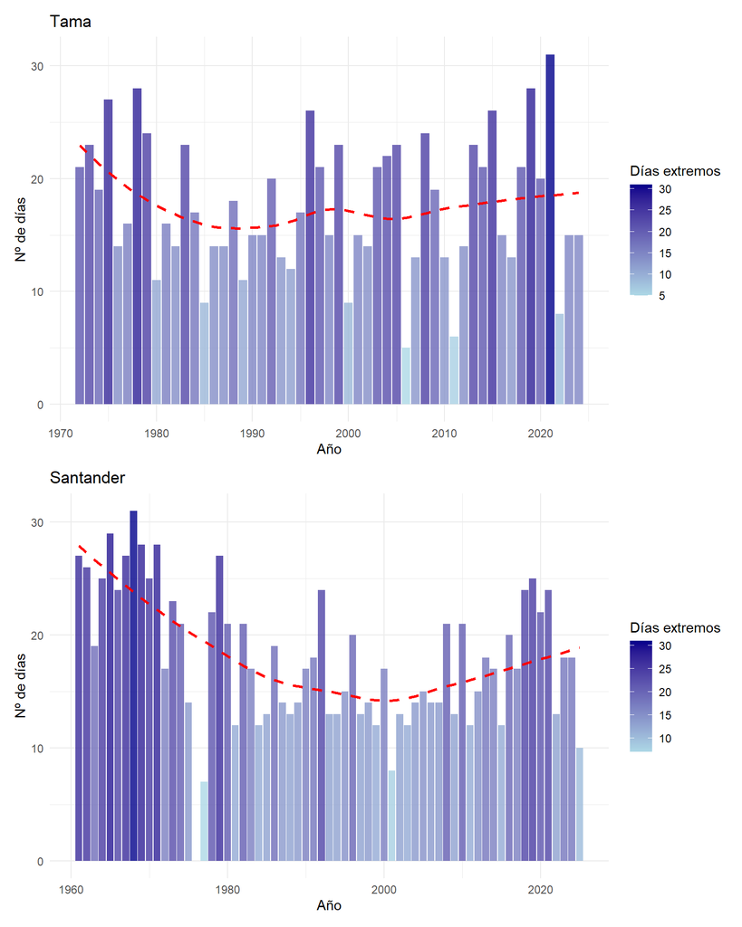

```r
# Función para graficar la evolución anual de días con precipitación extrema y su tendencia
plot_extremos_anuales <- function(df_anual, estacion) {

  ggplot(df_anual, aes(x = anio, y = dias_extremos)) +

    geom_col(aes(fill = dias_extremos), alpha = 0.8) +
    scale_fill_gradient(name = "Días extremos", low = "lightblue", high = "darkblue") +

    geom_smooth(method = "loess", se = FALSE, color = "red", linetype = "dashed") +

    labs(title = paste(estacion), x = "Año", y = "Nº de días") +

    theme_minimal()
}

# Generar y comparar las gráficas de días de precipitación extrema por año para cada estación
extremos_tama <- plot_extremos_anuales(lluviaExtrema_tama$resumen_anual, "Tama")
extremos_santander <- plot_extremos_anuales(lluviaExtrema_santander$resumen_anual, "Santander")

extremos_tama / extremos_santander
```

## 3.2 - Rachas de sequía y lluvia

`calcular_rachas()` detecta y caracteriza las rachas consecutivas de un estado meteorológico (*seco* o *lluvia*) a partir del vector de estados imputados (`estado_input`) o calculándolos directamente desde `prec` si no se proporciona. Usa `rle()` para identificar los bloques y genera un resumen con *duración*, *año*, *mes* y *día* de inicio y fin de cada racha.

Se aplica a ambas estaciones: Tama usa `estado_imputado_tama` (con los NA de 1-2 días ya resueltos), mientras que Santander lo calcula directamente desde `prec` dado que sus NA son escasos. Se calculan rachas tanto secas como lluviosas en el mismo paso para evitar repetir el procesamiento.

```r
# Función para identificar y resumir rachas consecutivas de estados seco/lluvia
# a partir de la precipitación o de una clasificación de estados proporcionada.
calcular_rachas <- function(df, umbral = 0.1, tipo, estado_input = NULL) {

  df <- df %>% arrange(anio, mes, dia)

  # Usar estados proporcionados o calcularlos a partir de la precipitación
  if (!is.null(estado_input)) {
    df$estado <- estado_input
  } else {
    df$estado <- ifelse(df$prec <= umbral, "seco",
                        ifelse(is.na(df$prec), NA, "lluvia"))
  }

  # Identificar bloques consecutivos de cada estado
  rle_seq <- rle(df$estado)

  rachas <- data.frame(longitud = rle_seq$lengths, valor = rle_seq$values)

  rachas$tipo_racha <- rachas$valor
  rachas$grupo <- seq_along(rachas$longitud)

  df$grupo_racha <- rep(rachas$grupo, rle_seq$lengths)
  df$tipo_racha <- rep(rachas$tipo_racha, rle_seq$lengths)

  # Resumir duración y fechas de inicio y fin de cada racha
  resumen <- df %>%
    group_by(grupo_racha, tipo_racha) %>%
    summarise(
      duracion = n(),
      inicio_anio = min(anio),
      inicio_mes = min(mes),
      inicio_dia = min(dia),
      fin_anio = max(anio),
      fin_mes = max(mes),
      fin_dia = max(dia),
      .groups = "drop"
    ) %>%
    filter(tipo_racha == tipo)

  return(list(datos = df, rachas = resumen))
}

# Calcular rachas secas para cada estación usando los estados disponibles
rachas_secas_tama <- calcular_rachas(datos_tama_con_NA, tipo = "seco", estado_input = estado_imputado_tama)
rachas_secas_santander <- calcular_rachas(datos_santander_limpios, tipo = "seco")

# Calcular rachas de lluvia e identificar eventos según duración mínima
rachas_lluviosas_tama <- calcular_rachas(datos_tama_con_NA, tipo = "lluvia", estado_input = estado_imputado_tama)
rachas_lluviosas_santander <- calcular_rachas(datos_santander_limpios, tipo = "lluvia")
```

### 3.2.1 - Filtrado de rachas por duración mínima y funciones gráficas

A continuación se filtran tres subconjuntos por duración mínima (3, 7 y 15 días) tanto para sequías como para lluvias, eliminando episodios muy cortos que podrían ser ruido o errores de medición sin significado meteorológico.

```r
# Filtrar rachas secas según diferentes duraciones mínimas
rachas_secas_tama_3dias <- rachas_secas_tama$rachas %>% filter(duracion >= 3)
rachas_secas_santander_3dias <- rachas_secas_santander$rachas %>% filter(duracion >= 3)

rachas_secas_tama_7dias <- rachas_secas_tama$rachas %>% filter(duracion >= 7)
rachas_secas_santander_7dias <- rachas_secas_santander$rachas %>% filter(duracion >= 7)

rachas_secas_tama_15dias <- rachas_secas_tama$rachas %>% filter(duracion >= 15)
rachas_secas_santander_15dias <- rachas_secas_santander$rachas %>% filter(duracion >= 15)
```

Definimos las dos funciones gráficas de propósito general que se reutilizan en todos los indicadores de rachas:

- `graficar_serie_anual()` crea un gráfico de línea para variables continuas (racha máxima anual, duración media), con una curva LOESS discontinua como tendencia suavizada.
- `graficar_histograma_anual()` crea barras (`geom_col`) para variables de conteo o porcentaje (número de rachas, porcentaje del año), añadiendo igualmente la curva LOESS. Ambas reciben parámetros de color separados para la serie y la tendencia, y el eje x es siempre inicio_anio.

```r
# Función para representar series temporales anuales con tendencia suavizada
graficar_serie_anual <- function(df, variable, titulo = "", ylab = "", color_punto = NULL, color_linea, color_tendencia = "black") {

  ggplot(df, aes(x = inicio_anio, y = .data[[variable]])) +
    geom_line(color = color_linea, linewidth = 0.5) +
    geom_smooth(method = "loess", se = FALSE, color = color_tendencia, linetype = "dashed") +
    labs(title = titulo, x = "Año", y = ylab) +
    theme_minimal()
}

# Función para representar variables anuales mediante barras y tendencia suavizada
graficar_histograma_anual <- function(df, variable, titulo = "", ylab = "", color_fill, color_linea) {

  ggplot(df, aes(x = inicio_anio, y = .data[[variable]])) +
    geom_col(fill = color_fill, alpha = 0.7) +
    geom_smooth(method = "loess", se = FALSE, color = color_linea, linetype = "dashed") +
    labs(title = titulo, x = "Año", y = ylab) +
    theme_minimal()
}
```

Se definen también las cuatro funciones de agregación anual:

- `racha_max()` devuelve la duración máxima de racha por año
- `num_rachas()` cuenta el número de rachas
- `duracion_media()` calcula la media de duraciones
- `porcentaje_tiempo_total_racha()` suma las duraciones y las expresa como porcentaje de 365 días.

```r
# Función para calcular la duración máxima anual de las rachas secas
racha_max <- function(rachas_df) {

  rachas_df %>%
    group_by(inicio_anio) %>%
    summarise(racha_max = max(duracion, na.rm = TRUE), .groups = "drop")
}

# Función para calcular el número anual de rachas secas
num_rachas <- function(rachas_df) {

  rachas_df %>%
    group_by(inicio_anio) %>%
    summarise(num_rachas = n(), .groups = "drop")
}

# Función para calcular la duración media anual de las rachas secas
duracion_media <- function(rachas_df) {

  rachas_df %>%
    group_by(inicio_anio) %>%
    summarise(duracion_media = mean(duracion, na.rm = TRUE), .groups = "drop")
}

# Función para calcular el tiempo anual ocupado por rachas secas
porcentaje_tiempo_total_racha <- function(rachas_df) {

  rachas_df %>%
    group_by(inicio_anio) %>%
    summarise(
      tiempo_total = sum(duracion, na.rm = TRUE),
      porcentaje_anual = (tiempo_total / 365) * 100,
      .groups = "drop"
    )
}
```

### 3.2.2 - Rachas de sequía

#### Racha máxima anual de sequía por año

Calculamos la racha seca máxima anual para cada estación usando `racha_max()` sobre el conjunto completo de rachas (sin filtro de duración mínima), para capturar también los eventos más extremos. Los gráficos de ambas estaciones comparten el mismo rango temporal en el eje x (`scale_x_continuous` con `limites_anios` calculados como el mínimo y máximo global) para que la comparación visual sea directa.

```r
# Calcular la racha seca máxima anual para cada estación
racha_max_anual_sequia_tama <- racha_max(rachas_secas_tama$rachas)
racha_max_anual_sequia_santander <- racha_max(rachas_secas_santander$rachas)
```

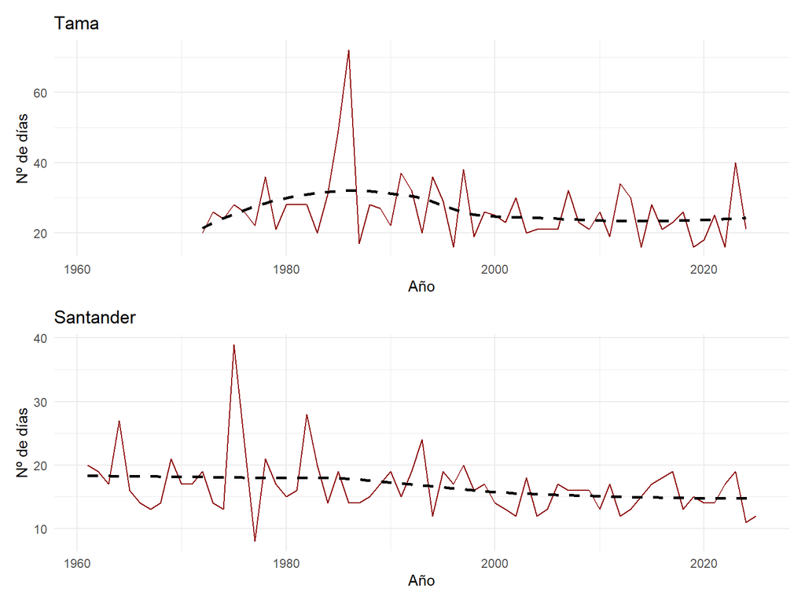

```r
# Graficar la evolución anual de la racha seca máxima para cada estación
limites_anios <- c(min(racha_max_anual_sequia_tama$inicio_anio, racha_max_anual_sequia_santander$inicio_anio),
                  max(racha_max_anual_sequia_tama$inicio_anio, racha_max_anual_sequia_santander$inicio_anio))

plot_sequia_max_tama <- graficar_serie_anual(
  racha_max_anual_sequia_tama,
  variable = "racha_max",
  titulo = "Tama",
  ylab = "Nº de días",
  color_linea = "darkred"
) + scale_x_continuous(limits = limites_anios)

plot_sequia_max_santander <- graficar_serie_anual(
  racha_max_anual_sequia_santander,
  variable = "racha_max",
  titulo = "Santander",
  ylab = "Nº de días",
  color_linea = "darkred"
) + scale_x_continuous(limits = limites_anios)

plot_sequia_max_tama / plot_sequia_max_santander
```

#### Número de rachas de sequía por año

Calculamos el número anual de rachas secas para cada estación y cada uno de los tres filtros de duración mínima (3, 7 y 15 días). El panel 3×2 resultante (filas = filtro de duración, columnas = estación) permite evaluar si una posible tendencia en el número de episodios secos es robusta frente al umbral de duración mínima elegido, o si depende de incluir o excluir los episodios muy cortos.

```r
# Calcular el número de rachas secas según duración mínima
num_rachas_sequia_tama_3dias <- num_rachas(rachas_secas_tama_3dias)
num_rachas_sequia_santander_3dias <- num_rachas(rachas_secas_santander_3dias)
num_rachas_sequia_tama_7dias <- num_rachas(rachas_secas_tama_7dias)
num_rachas_sequia_santander_7dias <- num_rachas(rachas_secas_santander_7dias)
num_rachas_sequia_tama_15dias <- num_rachas(rachas_secas_tama_15dias)
num_rachas_sequia_santander_15dias <- num_rachas(rachas_secas_santander_15dias)
```

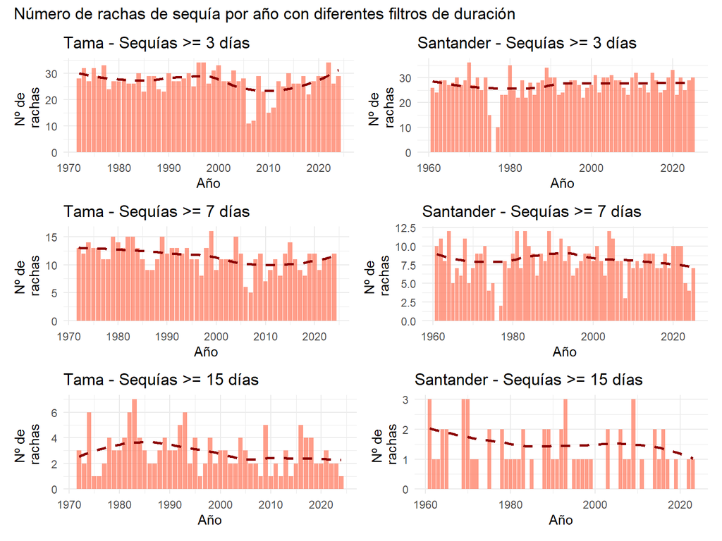

```r
# Graficar el número anual de rachas secas según duración mínima y estación
color_racha <- "coral1"
color_tendencia <- "darkred"

num_sequia_tama_3dias <- graficar_histograma_anual(num_rachas_sequia_tama_3dias, "num_rachas", "Tama - Sequías >= 3 días", "Nº de \nrachas", color_racha, color_tendencia)
num_sequia_tama_7dias <- graficar_histograma_anual(num_rachas_sequia_tama_7dias, "num_rachas", "Tama - Sequías >= 7 días", "Nº de \nrachas", color_racha, color_tendencia)
num_sequia_tama_15dias <- graficar_histograma_anual(num_rachas_sequia_tama_15dias, "num_rachas", "Tama - Sequías >= 15 días", "Nº de \nrachas", color_racha, color_tendencia)

num_sequia_santander_3dias <- graficar_histograma_anual(num_rachas_sequia_santander_3dias, "num_rachas", "Santander - Sequías >= 3 días", "Nº de \nrachas", color_racha, color_tendencia)
num_sequia_santander_7dias <- graficar_histograma_anual(num_rachas_sequia_santander_7dias, "num_rachas", "Santander - Sequías >= 7 días", "Nº de \nrachas", color_racha, color_tendencia)
num_sequia_santander_15dias <- graficar_histograma_anual(num_rachas_sequia_santander_15dias, "num_rachas", "Santander - Sequías >= 15 días", "Nº de \nrachas", color_racha, color_tendencia)

(num_sequia_tama_3dias | num_sequia_santander_3dias) /
(num_sequia_tama_7dias | num_sequia_santander_7dias) /
(num_sequia_tama_15dias | num_sequia_santander_15dias) +
  plot_annotation(title = "Número de rachas de sequía por año con diferentes filtros de duración")
```

#### Duración media de rachas de sequía por año

Calculamos la duración media anual de las rachas secas para cada estación y filtro de duración mínima. La visualización en panel 3×2 con escala de color permite comparar si la persistencia media de los episodios de sequía ha cambiado a lo largo del tiempo, de forma robusta frente al umbral elegido.

```r
# Calcular la duración media de rachas secas según duración mínima
duracion_media_sequia_tama_3dias <- duracion_media(rachas_secas_tama_3dias)
duracion_media_sequia_santander_3dias <- duracion_media(rachas_secas_santander_3dias)
duracion_media_sequia_tama_7dias <- duracion_media(rachas_secas_tama_7dias)
duracion_media_sequia_santander_7dias <- duracion_media(rachas_secas_santander_7dias)
duracion_media_sequia_tama_15dias <- duracion_media(rachas_secas_tama_15dias)
duracion_media_sequia_santander_15dias <- duracion_media(rachas_secas_santander_15dias)
```

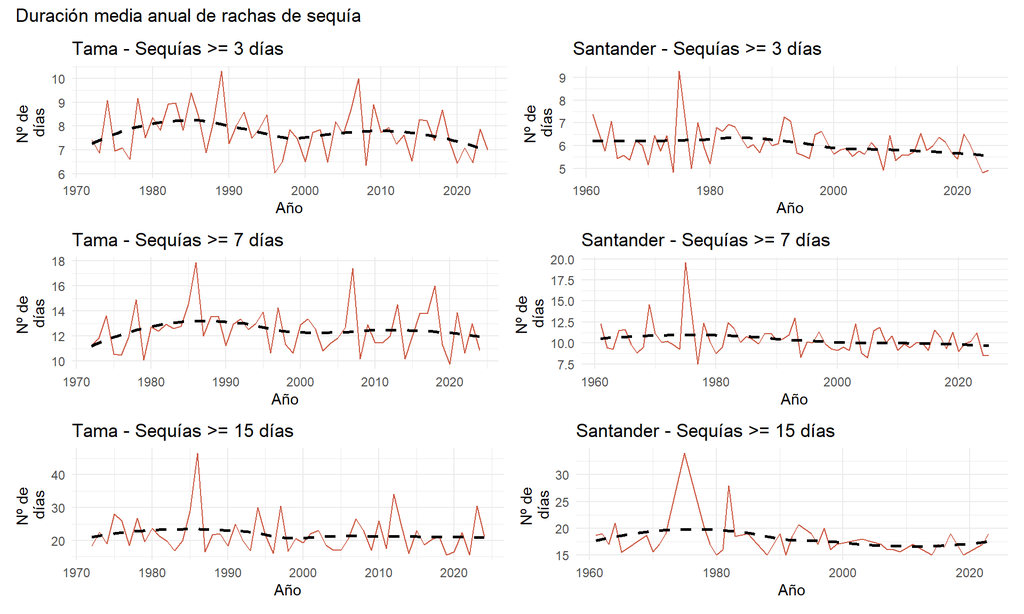

```r
# Graficar la duración media anual de las rachas secas según duración mínima y estación
color_racha <- "coral"
color_tendencia <- "coral3"

duracion_media_tama_3dias <- graficar_serie_anual(duracion_media_sequia_tama_3dias, "duracion_media", "Tama - Sequías >= 3 días", "Nº de \ndías", color_racha, color_tendencia)
duracion_media_tama_7dias <- graficar_serie_anual(duracion_media_sequia_tama_7dias, "duracion_media", "Tama - Sequías >= 7 días", "Nº de \ndías", color_racha, color_tendencia)
duracion_media_tama_15dias <- graficar_serie_anual(duracion_media_sequia_tama_15dias, "duracion_media", "Tama - Sequías >= 15 días", "Nº de \ndías", color_racha, color_tendencia)

duracion_media_santander_3dias <- graficar_serie_anual(duracion_media_sequia_santander_3dias, "duracion_media", "Santander - Sequías >= 3 días", "Nº de \ndías", color_racha, color_tendencia)
duracion_media_santander_7dias <- graficar_serie_anual(duracion_media_sequia_santander_7dias, "duracion_media", "Santander - Sequías >= 7 días", "Nº de \ndías", color_racha, color_tendencia)
duracion_media_santander_15dias <- graficar_serie_anual(duracion_media_sequia_santander_15dias, "duracion_media", "Santander - Sequías >= 15 días", "Nº de \ndías", color_racha, color_tendencia)

(duracion_media_tama_3dias | duracion_media_santander_3dias) /
(duracion_media_tama_7dias | duracion_media_santander_7dias) /
(duracion_media_tama_15dias | duracion_media_santander_15dias) +
  plot_annotation(title = "Duración media anual de rachas de sequía")
```

#### Porcentaje del tiempo total de sequía por año

Calculamos el porcentaje del año ocupado por rachas secas (suma de duraciones / 365 × 100) para cada estación y filtro de duración mínima. El panel 3×2 con barras en rojo ocre responde a la pregunta de si las sequías están ocupando una fracción creciente del año, más allá de si hay más episodios o si estos son más largos individualmente.

```r
# Calcular el porcentaje anual de tiempo en racha seca según duración mínima
tiempo_total_sequia_tama_3dias <- porcentaje_tiempo_total_racha(rachas_secas_tama_3dias)
tiempo_total_sequia_santander_3dias <- porcentaje_tiempo_total_racha(rachas_secas_santander_3dias)
tiempo_total_sequia_tama_7dias <- porcentaje_tiempo_total_racha(rachas_secas_tama_7dias)
tiempo_total_sequia_santander_7dias <- porcentaje_tiempo_total_racha(rachas_secas_santander_7dias)
tiempo_total_sequia_tama_15dias <- porcentaje_tiempo_total_racha(rachas_secas_tama_15dias)
tiempo_total_sequia_santander_15dias <- porcentaje_tiempo_total_racha(rachas_secas_santander_15dias)
```

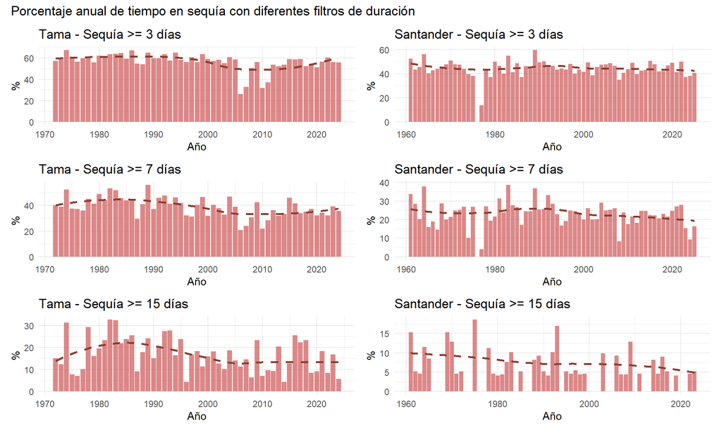

```r
# Graficar el porcentaje anual de tiempo en racha seca según duración mínima y estación
color_racha <- "indianred3"
color_tendencia <- "coral4"

porcentaje_total_sequia_anual_tama_3dias <- graficar_histograma_anual(tiempo_total_sequia_tama_3dias, "porcentaje_anual", "Tama - Sequía >= 3 días", "%", color_racha, color_tendencia)
porcentaje_total_sequia_anual_tama_7dias <- graficar_histograma_anual(tiempo_total_sequia_tama_7dias, "porcentaje_anual", "Tama - Sequía >= 7 días", "%", color_racha, color_tendencia)
porcentaje_total_sequia_anual_tama_15dias <- graficar_histograma_anual(tiempo_total_sequia_tama_15dias, "porcentaje_anual", "Tama - Sequía >= 15 días", "%", color_racha, color_tendencia)

porcentaje_total_sequia_anual_santander_3dias <- graficar_histograma_anual(tiempo_total_sequia_santander_3dias, "porcentaje_anual", "Santander - Sequía >= 3 días", "%", color_racha, color_tendencia)
porcentaje_total_sequia_anual_santander_7dias <- graficar_histograma_anual(tiempo_total_sequia_santander_7dias, "porcentaje_anual", "Santander - Sequía >= 7 días", "%", color_racha, color_tendencia)
porcentaje_total_sequia_anual_santander_15dias <- graficar_histograma_anual(tiempo_total_sequia_santander_15dias, "porcentaje_anual", "Santander - Sequía >= 15 días", "%", color_racha, color_tendencia)

(porcentaje_total_sequia_anual_tama_3dias | porcentaje_total_sequia_anual_santander_3dias) /
(porcentaje_total_sequia_anual_tama_7dias | porcentaje_total_sequia_anual_santander_7dias) /
(porcentaje_total_sequia_anual_tama_15dias | porcentaje_total_sequia_anual_santander_15dias) +
  plot_annotation(title = "Porcentaje anual de tiempo en sequía con diferentes filtros de duración")
```

### 3.2.3 - Rachas de lluvia

Aplicamos los mismos cuatro indicadores anuales al análisis de rachas lluviosas, usando una paleta de azules para diferenciar visualmente este bloque del de sequías. Los filtros de duración mínima son idénticos (3, 7 y 15 días).

```r
# Filtrar rachas de lluvia según diferentes duraciones mínimas
rachas_lluviosas_tama_3dias <- rachas_lluviosas_tama$rachas %>% filter(duracion >= 3)
rachas_lluviosas_santander_3dias <- rachas_lluviosas_santander$rachas %>% filter(duracion >= 3)

rachas_lluviosas_tama_7dias <- rachas_lluviosas_tama$rachas %>% filter(duracion >= 7)
rachas_lluviosas_santander_7dias <- rachas_lluviosas_santander$rachas %>% filter(duracion >= 7)

rachas_lluviosas_tama_15dias <- rachas_lluviosas_tama$rachas %>% filter(duracion >= 15)
rachas_lluviosas_santander_15dias <- rachas_lluviosas_santander$rachas %>% filter(duracion >= 15)
```

#### Racha máxima anual de lluvias por año

Para los gráficos de racha máxima se usa el mismo criterio de eje temporal compartido que en el análisis de sequía.

```r
# Racha máxima anual de lluvias por año
racha_max_anual_lluvia_tama <- racha_max(rachas_lluviosas_tama$rachas)
racha_max_anual_lluvia_santander <- racha_max(rachas_lluviosas_santander$rachas)
```

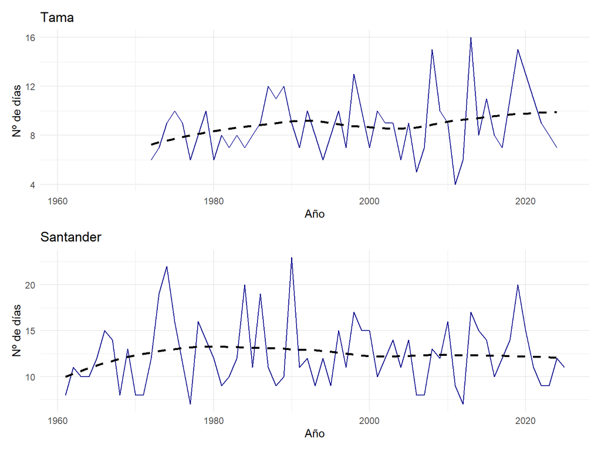

```r
# Graficar la evolución anual de la racha máxima de lluvia para cada estación
limites_anios <- c(min(racha_max_anual_lluvia_tama$inicio_anio, racha_max_anual_lluvia_santander$inicio_anio),
                  max(racha_max_anual_lluvia_tama$inicio_anio, racha_max_anual_lluvia_santander$inicio_anio))

plot_lluvia_max_tama <- graficar_serie_anual(racha_max_anual_lluvia_tama, "racha_max", "Tama", "Nº de días", color_linea = "darkblue") +
  scale_x_continuous(limits = limites_anios)

plot_lluvia_max_santander <- graficar_serie_anual(racha_max_anual_lluvia_santander, "racha_max", "Santander", "Nº de días", color_linea = "darkblue") +
  scale_x_continuous(limits = limites_anios)

plot_lluvia_max_tama / plot_lluvia_max_santander
```

#### Número de rachas de lluvia por año

```r
# Calcular el número anual de rachas de lluvia según duración mínima
num_rachas_lluvia_tama_3dias <- num_rachas(rachas_lluviosas_tama_3dias)
num_rachas_lluvia_santander_3dias <- num_rachas(rachas_lluviosas_santander_3dias)
num_rachas_lluvia_tama_7dias <- num_rachas(rachas_lluviosas_tama_7dias)
num_rachas_lluvia_santander_7dias <- num_rachas(rachas_lluviosas_santander_7dias)
num_rachas_lluvia_tama_15dias <- num_rachas(rachas_lluviosas_tama_15dias)
num_rachas_lluvia_santander_15dias <- num_rachas(rachas_lluviosas_santander_15dias)
```

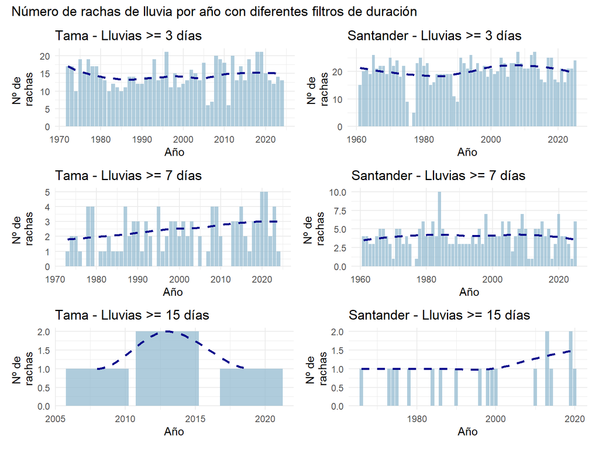

```r
# Graficar el número anual de rachas de lluvia según duración mínima y estación
color_racha <- "lightskyblue3"
color_tendencia <- "darkblue"

num_lluvia_tama_3dias <- graficar_histograma_anual(num_rachas_lluvia_tama_3dias, "num_rachas", "Tama - Lluvias >= 3 días", "Nº de \nrachas", color_racha, color_tendencia)
num_lluvia_tama_7dias <- graficar_histograma_anual(num_rachas_lluvia_tama_7dias, "num_rachas", "Tama - Lluvias >= 7 días", "Nº de \nrachas", color_racha, color_tendencia)
num_lluvia_tama_15dias <- graficar_histograma_anual(num_rachas_lluvia_tama_15dias, "num_rachas", "Tama - Lluvias >= 15 días", "Nº de \nrachas", color_racha, color_tendencia)

num_lluvia_santander_3dias <- graficar_histograma_anual(num_rachas_lluvia_santander_3dias, "num_rachas", "Santander - Lluvias >= 3 días", "Nº de \nrachas", color_racha, color_tendencia)
num_lluvia_santander_7dias <- graficar_histograma_anual(num_rachas_lluvia_santander_7dias, "num_rachas", "Santander - Lluvias >= 7 días", "Nº de \nrachas", color_racha, color_tendencia)
num_lluvia_santander_15dias <- graficar_histograma_anual(num_rachas_lluvia_santander_15dias, "num_rachas", "Santander - Lluvias >= 15 días", "Nº de \nrachas", color_racha, color_tendencia)

(num_lluvia_tama_3dias | num_lluvia_santander_3dias) /
(num_lluvia_tama_7dias | num_lluvia_santander_7dias) /
(num_lluvia_tama_15dias | num_lluvia_santander_15dias) +
  plot_annotation(title = "Número de rachas de lluvia por año con diferentes filtros de duración")
```

#### Duración media de rachas de lluvia por año

```r
# Calcular la duración media anual de rachas de lluvia según duración mínima
duracion_media_lluvia_tama_3dias <- duracion_media(rachas_lluviosas_tama_3dias)
duracion_media_lluvia_santander_3dias <- duracion_media(rachas_lluviosas_santander_3dias)
duracion_media_lluvia_tama_7dias <- duracion_media(rachas_lluviosas_tama_7dias)
duracion_media_lluvia_santander_7dias <- duracion_media(rachas_lluviosas_santander_7dias)
duracion_media_lluvia_tama_15dias <- duracion_media(rachas_lluviosas_tama_15dias)
duracion_media_lluvia_santander_15dias <- duracion_media(rachas_lluviosas_santander_15dias)
```

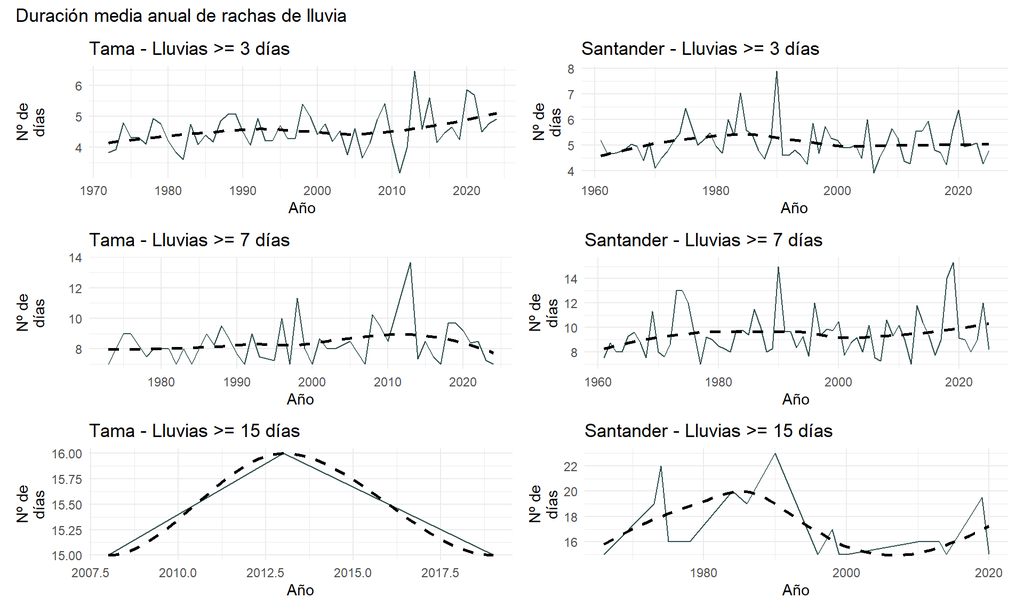

```r
# Graficar la duración media anual de rachas de lluvia según duración mínima y estación
color_racha <- "#528B8B"
color_tendencia <- "#2F4F4F"

plot_duracion_media_lluvia_tama_3dias <- graficar_serie_anual(duracion_media_lluvia_tama_3dias, "duracion_media", "Tama - Lluvias >= 3 días", "Nº de\ndías", color_racha, color_tendencia)
plot_duracion_media_lluvia_tama_7dias <- graficar_serie_anual(duracion_media_lluvia_tama_7dias, "duracion_media", "Tama - Lluvias >= 7 días", "Nº de\ndías", color_racha, color_tendencia)
plot_duracion_media_lluvia_tama_15dias <- graficar_serie_anual(duracion_media_lluvia_tama_15dias, "duracion_media", "Tama - Lluvias >= 15 días", "Nº de\ndías", color_racha, color_tendencia)

plot_duracion_media_lluvia_santander_3dias <- graficar_serie_anual(duracion_media_lluvia_santander_3dias, "duracion_media", "Santander - Lluvias >= 3 días", "Nº de\ndías", color_racha, color_tendencia)
plot_duracion_media_lluvia_santander_7dias <- graficar_serie_anual(duracion_media_lluvia_santander_7dias, "duracion_media", "Santander - Lluvias >= 7 días", "Nº de\ndías", color_racha, color_tendencia)
plot_duracion_media_lluvia_santander_15dias <- graficar_serie_anual(duracion_media_lluvia_santander_15dias, "duracion_media", "Santander - Lluvias >= 15 días", "Nº de\ndías", color_racha, color_tendencia)

(plot_duracion_media_lluvia_tama_3dias | plot_duracion_media_lluvia_santander_3dias) /
(plot_duracion_media_lluvia_tama_7dias | plot_duracion_media_lluvia_santander_7dias) /
(plot_duracion_media_lluvia_tama_15dias | plot_duracion_media_lluvia_santander_15dias) +
  plot_annotation(title = "Duración media anual de rachas de lluvia")
```

#### Porcentaje del tiempo total de lluvia por año

```r
# Calcular el porcentaje anual de tiempo ocupado por rachas de lluvia según duración mínima
tiempo_total_lluvia_tama_3dias <- porcentaje_tiempo_total_racha(rachas_lluviosas_tama_3dias)
tiempo_total_lluvia_santander_3dias <- porcentaje_tiempo_total_racha(rachas_lluviosas_santander_3dias)
tiempo_total_lluvia_tama_7dias <- porcentaje_tiempo_total_racha(rachas_lluviosas_tama_7dias)
tiempo_total_lluvia_santander_7dias <- porcentaje_tiempo_total_racha(rachas_lluviosas_santander_7dias)
tiempo_total_lluvia_tama_15dias <- porcentaje_tiempo_total_racha(rachas_lluviosas_tama_15dias)
tiempo_total_lluvia_santander_15dias <- porcentaje_tiempo_total_racha(rachas_lluviosas_santander_15dias)
```

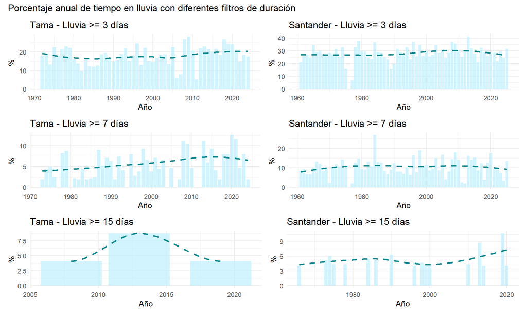

```r
# Graficar el porcentaje anual de tiempo en rachas de lluvia según duración mínima y estación
color_racha <- "lightblue1"
color_tendencia <- "turquoise4"

porcentaje_total_lluvia_anual_tama_3dias <- graficar_histograma_anual(tiempo_total_lluvia_tama_3dias, "porcentaje_anual", "Tama - Lluvia >= 3 días", "%", color_racha, color_tendencia)
porcentaje_total_lluvia_anual_tama_7dias <- graficar_histograma_anual(tiempo_total_lluvia_tama_7dias, "porcentaje_anual", "Tama - Lluvia >= 7 días", "%", color_racha, color_tendencia)
porcentaje_total_lluvia_anual_tama_15dias <- graficar_histograma_anual(tiempo_total_lluvia_tama_15dias, "porcentaje_anual", "Tama - Lluvia >= 15 días", "%", color_racha, color_tendencia)

porcentaje_total_lluvia_anual_santander_3dias <- graficar_histograma_anual(tiempo_total_lluvia_santander_3dias, "porcentaje_anual", "Santander - Lluvia >= 3 días", "%", color_racha, color_tendencia)
porcentaje_total_lluvia_anual_santander_7dias <- graficar_histograma_anual(tiempo_total_lluvia_santander_7dias, "porcentaje_anual", "Santander - Lluvia >= 7 días", "%", color_racha, color_tendencia)
porcentaje_total_lluvia_anual_santander_15dias <- graficar_histograma_anual(tiempo_total_lluvia_santander_15dias, "porcentaje_anual", "Santander - Lluvia >= 15 días", "%", color_racha, color_tendencia)

(porcentaje_total_lluvia_anual_tama_3dias | porcentaje_total_lluvia_anual_santander_3dias) /
(porcentaje_total_lluvia_anual_tama_7dias | porcentaje_total_lluvia_anual_santander_7dias) /
(porcentaje_total_lluvia_anual_tama_15dias | porcentaje_total_lluvia_anual_santander_15dias) +
  plot_annotation(title = "Porcentaje anual de tiempo en lluvia con diferentes filtros de duración")
```

# Sección 4 - Evolución del régimen pluviométrico anual

## 4.1 - Criterio de calidad de los años

Antes de calcular los indicadores anuales de precipitación es necesario evaluar qué años tienen cobertura suficiente, para poder señalar visualmente en las gráficas correspondientes los años que se consideraron no válidos para los análisis por tener una conbertura insuficiente.

```r
# Evaluación de años válidos según cobertura de datos disponible
umbral_dias <- 330  # ~90,4% de cobertura anual (criterio OMM)

# Función para identificar años válidos con posibilidad de excepciones controladas
anios_validos <- function(df_sin_na, excepciones = integer(0), umbral_excepcion = 300) {
  df_sin_na %>%
    group_by(anio) %>%
    summarise(dias_con_dato = n(), .groups = "drop") %>%
    mutate(
      es_excepcion = anio %in% excepciones & dias_con_dato >= umbral_excepcion,
      anio_valido = dias_con_dato >= umbral_dias | es_excepcion
    )
}

# Aplicar criterio de calidad a cada estación
calidad_tama <- anios_validos(datos_tama_sin_NA, excepciones = c(1985L), umbral_excepcion = 300)
calidad_santander <- anios_validos(datos_santander_limpios)
```

La tabla de calidad generada documenta todos los años que no superan el umbral en cada estación y las excepciones admitidas, garantizando trazabilidad completa de las decisiones de tratamiento.

```r
# Tabla de años que no cumplen el criterio de calidad o tienen excepción aplicada
bind_rows(
  calidad_tama %>% mutate(estacion = "Tama"),
  calidad_santander %>% mutate(estacion = "Santander")
) %>%
  filter(!anio_valido | es_excepcion) %>%
  arrange(estacion, anio) %>%
  select(estacion, anio, dias_con_dato, es_excepcion, anio_valido) %>%
  knitr::kable(
    col.names = c("Estación", "Año", "Días con dato", "Excepción aplicada", "Año válido"),
    caption = "Años con cobertura inferior al criterio de calidad establecido (330 días/año) y excepciones admitidas."
  ) %>%
  kableExtra::kable_styling(
    bootstrap_options = c("striped", "hover"),
    full_width = FALSE
  )
```

Años con cobertura inferior al criterio de calidad establecido (330 días/año) y excepciones admitidas.

| Estación | Año | Días con dato | Excepción aplicada | Año válido |
| --- | --- | --- | --- | --- |
| Santander | 1975 | 221 | FALSE | FALSE |
| Santander | 1977 | 122 | FALSE | FALSE |
| Tama | 1985 | 325 | TRUE | TRUE |
| Tama | 2006 | 153 | FALSE | FALSE |
| Tama | 2007 | 200 | FALSE | FALSE |
| Tama | 2010 | 243 | FALSE | FALSE |
| Tama | 2011 | 209 | FALSE | FALSE |

## 4.2 - Indicadores anuales de precipitación

`calculos_precipitacion()` calcula los tres indicadores anuales principales del régimen de precipitación: `total_prec` (suma anual en mm), `dias_lluvia` (número de días con prec > 0.1 mm) e `intensidad_media` (`total_prec` / `dias_lluvia`, NA si no hubo días de lluvia). Incorpora la tabla de calidad mediante `left_join` para que anio_valido esté disponible en las funciones de visualización.

```r
# Función para calcular precipitación anual, días de lluvia e intensidad media
calculos_precipitacion <- function(df, calidad) {
  df %>%
    group_by(anio) %>%
    summarise(
      total_prec = sum(prec, na.rm = TRUE),
      dias_lluvia = sum(lluvia == TRUE, na.rm = TRUE),
      intensidad_media = ifelse(dias_lluvia > 0, total_prec / dias_lluvia, NA),
      .groups = "drop"
    ) %>%
    left_join(calidad, by = "anio")
}

# Calcular variables de precipitación para cada estación
intensidad_tama <- calculos_precipitacion(datos_tama_sin_NA, calidad_tama)
intensidad_santander <- calculos_precipitacion(datos_santander_limpios, calidad_santander)

# Unir estaciones y calcular medias móviles de las variables de precipitación
df_intensidad <- bind_rows(
  intensidad_tama %>% mutate(estacion = "Tama"),
  intensidad_santander %>% mutate(estacion = "Santander")
) %>%
  group_by(estacion) %>%
  arrange(anio) %>%
  mutate(
    media_movil_prec = zoo::rollmean(total_prec, k = 5, fill = NA, align = "center"),
    media_movil_int = zoo::rollmean(intensidad_media, k = 5, fill = NA, align = "center"),
    media_movil_dias_lluvia = zoo::rollmean(dias_lluvia, k = 5, fill = NA, align = "center")
  ) %>%
  ungroup()
```

Las tres funciones de visualización responden a las preguntas centrales del análisis:

- `plot_precipitacion_total()` muestra la precipitación total anual como barras (azul = válido, salmón = incompleto) con la media móvil en azul oscuro
- `plot_dias_lluvia()` hace lo mismo para los días con lluvia en lila con media móvil orchid4
- `plot_intensidad_media()` representa la intensidad como línea continua verde con la media móvil en verde claro, marcando los años inválidos con una cruz (×) dado que no hay distinción de color de relleno.

### 4.2.1 - Precipitación total anual

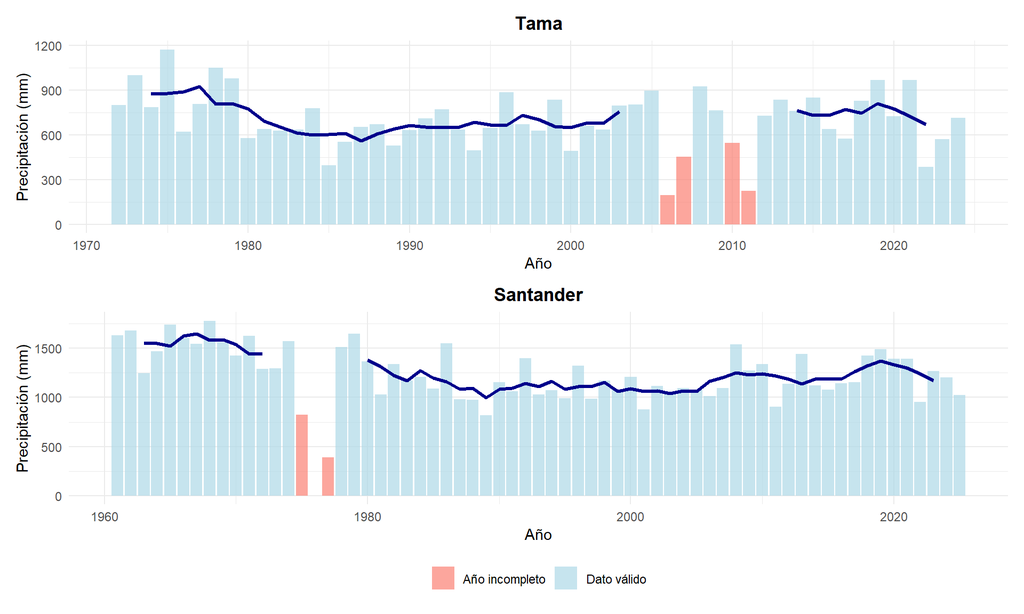

```r
# Función para representar la precipitación anual y su tendencia mediante media móvil
plot_precipitacion_total <- function(df, estacion, window = 5, mostrar_leyenda = TRUE) {

  df <- df %>%
    arrange(anio) %>%
    mutate(media_movil = zoo::rollmean(ifelse(anio_valido, total_prec, NA),
                                       k = window, fill = NA, align = "center"))

  ggplot(df, aes(x = anio)) +
    geom_col(aes(y = total_prec, fill = anio_valido), alpha = 0.7) +
    scale_fill_manual(
      values = c("TRUE" = "lightblue", "FALSE" = "salmon"),
      labels = c("TRUE" = "Dato válido", "FALSE" = "Año incompleto"),
      name = NULL
    ) +
    geom_line(aes(y = media_movil), color = "darkblue", size = 1.2) +
    labs(title = estacion, y = "Precipitación (mm)", x = "Año") +
    theme_minimal() +
    theme(plot.title = element_text(hjust = 0.5, face = "bold"),
          legend.position = ifelse(mostrar_leyenda, "bottom", "none"))
}

# Generar gráficas para cada estación
precipitacion_total_tama <- plot_precipitacion_total(intensidad_tama, "Tama", mostrar_leyenda = FALSE)
precipitacion_total_santander <- plot_precipitacion_total(intensidad_santander, "Santander")

precipitacion_total_tama / precipitacion_total_santander
```

### 4.2.2 - Número de días de lluvia

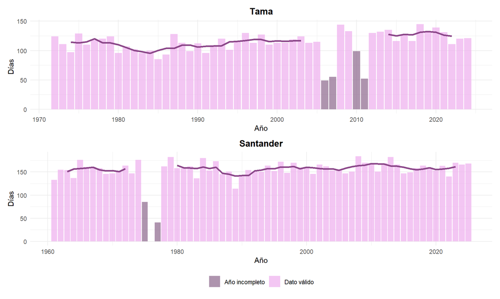

```r
# Función para representar los días de lluvia anuales y su tendencia mediante media móvil
plot_dias_lluvia <- function(df_intensidad, estacion, window = 5, mostrar_leyenda = TRUE) {

  df_intensidad <- df_intensidad %>%
    arrange(anio) %>%
    mutate(media_movil = zoo::rollmean(ifelse(anio_valido, dias_lluvia, NA),
                                       k = window, fill = NA, align = "center"))

  ggplot(df_intensidad, aes(x = anio, y = dias_lluvia)) +
    geom_col(aes(fill = anio_valido), alpha = 0.7) +
    scale_fill_manual(
      values = c("TRUE" = "plum2", "FALSE" = "plum4"),
      labels = c("TRUE" = "Dato válido", "FALSE" = "Año incompleto"),
      name = NULL
    ) +
    geom_line(aes(y = media_movil), color = "orchid4", linewidth = 1.1) +
    labs(title = estacion, x = "Año", y = "Días") +
    theme_minimal() +
    theme(
      plot.title = element_text(hjust = 0.5, face = "bold"),
      legend.position = ifelse(mostrar_leyenda, "bottom", "none")
    )
}

# Generar gráficas para cada estación
dias_lluvia_tama <- plot_dias_lluvia(intensidad_tama, "Tama", mostrar_leyenda = FALSE)
dias_lluvia_santander <- plot_dias_lluvia(intensidad_santander, "Santander")

dias_lluvia_tama / dias_lluvia_santander
```

### 4.2.3 - Intensidad media anual de precipitación

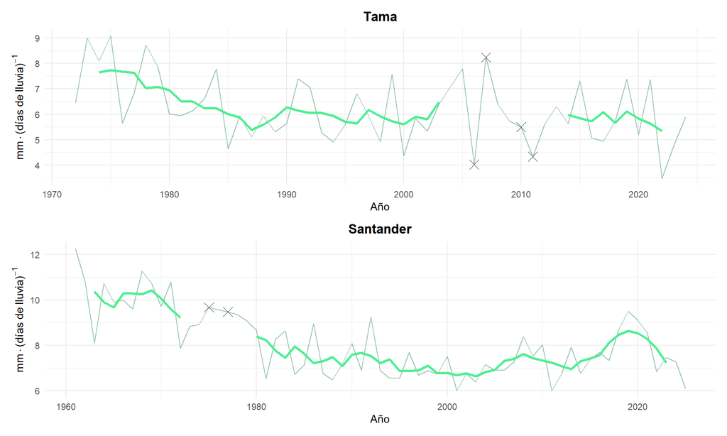

```r
# Función para representar la intensidad media anual de precipitación y su tendencia
plot_intensidad_media <- function(df, estacion, window = 5) {

  df <- df %>%
    arrange(anio) %>%
    mutate(media_movil = zoo::rollmean(ifelse(anio_valido, intensidad_media, NA),
                                       k = window, fill = NA, align = "center"))

  ggplot(df, aes(x = anio)) +
    geom_line(aes(y = intensidad_media), color = "seagreen", alpha = 0.5) +
    geom_point(
      data = filter(df, !anio_valido),
      aes(y = intensidad_media),
      color = "black", size = 4, shape = 4
    ) +
    geom_line(aes(y = media_movil), color = "seagreen2", linewidth = 1.2) +
    labs(
      title = estacion,
      y = expression(mm %.% "(" * días~de~lluvia * ")"^{-1}),
      x = "Año"
    ) +
    theme_minimal() +
    theme(
      plot.title = element_text(hjust = 0.5, face = "bold"),
      legend.position = "bottom"
    )
}

# Generar gráficas para cada estación
intensidad_media_tama <- plot_intensidad_media(intensidad_tama, "Tama")
intensidad_media_santander <- plot_intensidad_media(intensidad_santander, "Santander")

intensidad_media_tama / intensidad_media_santander
```

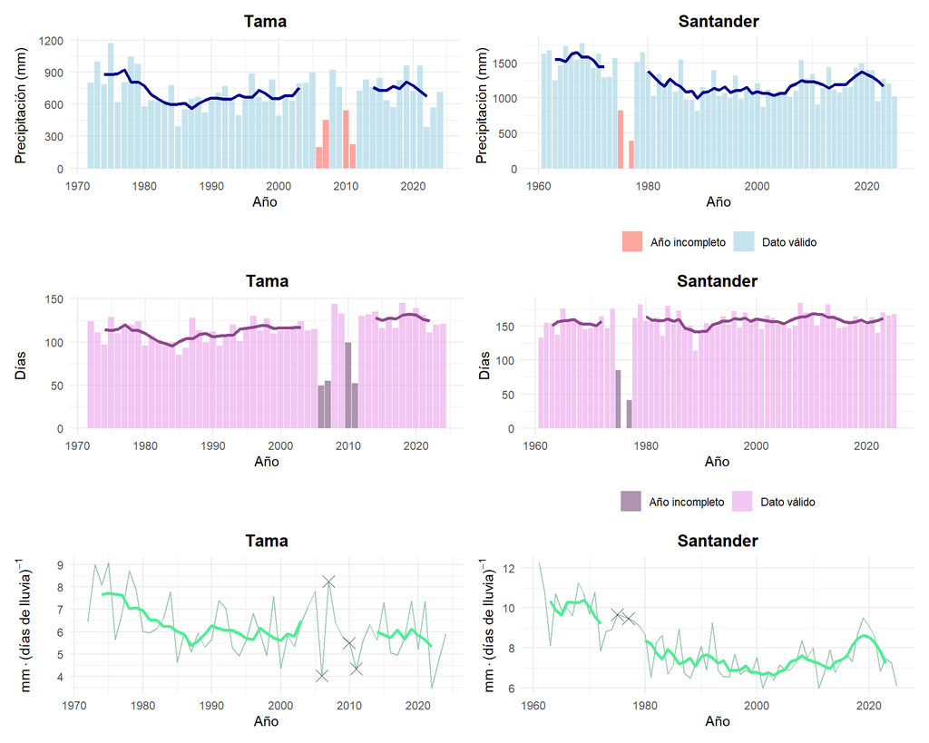

```r
# Comparación conjunta de precipitación total, días de lluvia e intensidad media por estación
(precipitacion_total_tama | precipitacion_total_santander) /
(dias_lluvia_tama | dias_lluvia_santander) /
(intensidad_media_tama | intensidad_media_santander)
```

# Sección 5 - Comparación temporal de la persistencia de las rachas secas

## 5.1 - Distribución de duración de rachas

`comparar_distribuciones_rachas()` genera gráficos de densidad kernel superpuestos para comparar la distribución de duración de rachas secas entre el periodo histórico (hasta 1995, en dorado) y el reciente (desde 1996, en verde). El relleno semitransparente (alpha = 0.35) y el contorno más grueso (geom_density con fill = NA) permiten ver la forma de cada distribución con claridad. El eje x se limita a 40 días para centrar la atención en el rango con observaciones suficientes. El panel 3×2 compara los tres filtros de duración mínima por estación; las leyendas se suprimen en los paneles superiores.

```r
# Función para comparar la distribución de duración de rachas entre dos periodos
comparar_distribuciones_rachas <- function(rachas_df, corte_anio = 1995,
                                           titulo = NULL, mostrar_leyenda = TRUE) {

  rachas_df$periodo <- ifelse(rachas_df$inicio_anio <= corte_anio,
                              "Histórico", "Reciente")

  cols_fill <- c("Histórico" = "goldenrod1", "Reciente" = "seagreen2")
  cols_line <- c("Histórico" = "goldenrod4", "Reciente" = "seagreen4")

  p <- ggplot(rachas_df, aes(x = duracion, fill = periodo, colour = periodo)) +
    geom_density(alpha = 0.35, size = 0.6) +
    geom_density(aes(y = ..density..), colour = NA, alpha = 0) +
    geom_density(fill = NA, size = 1.2, alpha = 1) +
    scale_fill_manual(values = cols_fill) +
    scale_colour_manual(values = cols_line,
                        guide = guide_legend(override.aes = list(fill = NA))) +
    labs(x = "Duración / días", y = "Densidad") +
    xlim(0, 40) +
    theme_minimal()

  p <- p + theme(legend.position = ifelse(mostrar_leyenda, "bottom", "none"))

  if (!is.null(titulo)) p <- p + labs(title = titulo)

  p
}
```

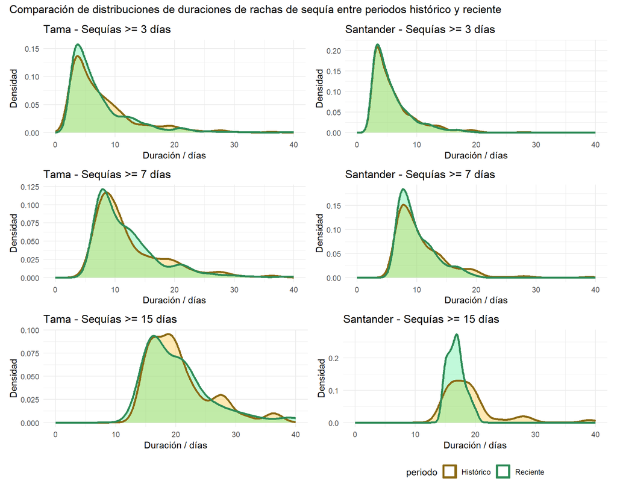

```r
# Comparación de distribuciones de duración de rachas de sequía por estación y umbral
comparacion_tama_3 <- comparar_distribuciones_rachas(rachas_secas_tama_3dias, 1995, "Tama - Sequías >= 3 días", FALSE)
comparacion_santander_3 <- comparar_distribuciones_rachas(rachas_secas_santander_3dias, 1995, "Santander - Sequías >= 3 días", FALSE)

comparacion_tama_7 <- comparar_distribuciones_rachas(rachas_secas_tama_7dias, 1995, "Tama - Sequías >= 7 días", FALSE)
comparacion_santander_7 <- comparar_distribuciones_rachas(rachas_secas_santander_7dias, 1995, "Santander - Sequías >= 7 días", FALSE)

comparacion_tama_15 <- comparar_distribuciones_rachas(rachas_secas_tama_15dias, 1995, "Tama - Sequías >= 15 días", FALSE)
comparacion_santander_15 <- comparar_distribuciones_rachas(rachas_secas_santander_15dias, 1995, "Santander - Sequías >= 15 días")

(comparacion_tama_3 | comparacion_santander_3) /
(comparacion_tama_7 | comparacion_santander_7) /
(comparacion_tama_15 | comparacion_santander_15) +
  plot_annotation(title = "Comparación de distribuciones de duraciones de rachas de sequía entre periodos histórico y reciente")
```

## 5.2 - ECDF (función de distribución acumulada)

`comparar_ecdf()` construye la función de distribución acumulada empírica (ECDF) de las duraciones de rachas secas usando geom_step con `stat` = “ecdf”, sin suavizado ni bins arbitrarios. Cada estación aparece en una faceta separada.

La función `crear_ecdf()` simplifica la llamada combinando los datos de ambas estaciones con `bind_rows()` (añadiendo la columna `estacion`) y llamando a `comparar_ecdf()` con el filtro de duración indicado. El panel horizontal triple con los tres filtros permite evaluar la robustez del resultado: si la ausencia de cambio entre periodos se mantiene con los tres umbrales, la conclusión es sólida e independiente del umbral elegido.

```r
# Función para comparar la ECDF de duraciones de rachas entre periodos y estaciones
comparar_ecdf <- function(rachas_df, corte_anio = 1995,
                          titulo = "ECDF de duraciones de rachas por periodo",
                          mostrar_leyenda = TRUE) {

  rachas_df <- rachas_df %>%
    mutate(periodo = ifelse(inicio_anio <= corte_anio, "Histórico", "Reciente"),
           estacion = as.factor(estacion)
    )

  p <- ggplot(rachas_df, aes(duracion, color = periodo)) +
    geom_step(stat = "ecdf", linewidth = 1) +
    facet_wrap(~estacion) +
    labs(x = "Duración / días", y = "ECDF", title = titulo) +
    scale_color_manual(values = c("Histórico" = "goldenrod2", "Reciente" = "seagreen3")) +
    theme_minimal() +
    theme(legend.position = ifelse(mostrar_leyenda, "bottom", "none"))

  p
}
```

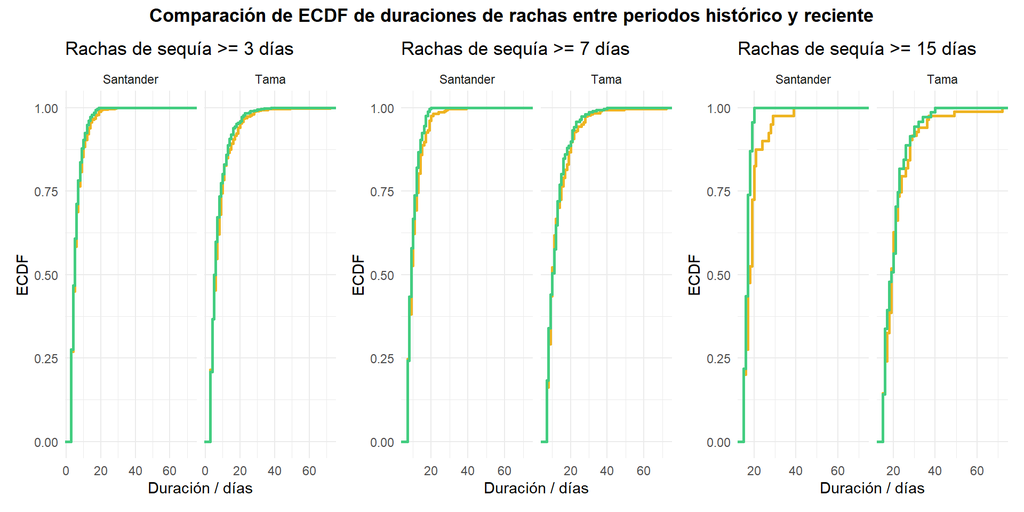

```r
# Preparar datos y graficar ECDF para distintos filtros de duración de rachas
crear_ecdf <- function(tama, santander, filtro) {
  df <- bind_rows(
    tama %>% mutate(estacion = "Tama"),
    santander %>% mutate(estacion = "Santander")
  )
  comparar_ecdf(df, corte_anio = 1995,
                titulo = paste("Rachas de sequía >=", filtro, "días"),
                mostrar_leyenda = FALSE)
}

ecdf_3dias  <- crear_ecdf(rachas_secas_tama_3dias, rachas_secas_santander_3dias, 3)
ecdf_7dias  <- crear_ecdf(rachas_secas_tama_7dias, rachas_secas_santander_7dias, 7)
ecdf_15dias <- crear_ecdf(rachas_secas_tama_15dias, rachas_secas_santander_15dias, 15)

(ecdf_3dias | ecdf_7dias | ecdf_15dias) +
  plot_annotation(title = "Comparación de ECDF de duraciones de rachas entre periodos histórico y reciente",
                  theme = theme(plot.title = element_text(hjust = 0.5, face = "bold")))
```

## 5.3 - Distribución mensual del número de rachas y duración media

Para la comparación por mes entre periodos definimos los parámetros globales (`corte_anio` = 1995, paleta dorado/verde) y la función auxiliar `etiquetar_periodos()`, que añade la columna `periodo` y `mes_label` como factor ordenado de enero a diciembre a cualquier dataframe de rachas.

- `plot_rachas_por_mes()` genera barras agrupadas por mes y periodo mostrando el número total de rachas iniciadas cada mes, respondiendo a si hay meses en los que las sequías se están volviendo más frecuentes.
- `plot_duracion_media_mes()` genera barras análogas con la duración media de las rachas iniciadas en cada mes, respondiendo a si en algún mes las sequías están siendo más largas.
- `comparar_rachas_mes()` combina ambas funciones en un panel 2×2 para cada filtro de duración mínima, aplicándose a los tres filtros de forma iterativa.

```r
# Parámetros y función para clasificar rachas según periodo histórico o reciente
corte_anio <- 1995
cols_fill <- c("Histórico" = "goldenrod2", "Reciente" = "seagreen3")
nombres_meses <- c("Ene", "Feb", "Mar", "Abr", "May", "Jun", "Jul", "Ago", "Sep", "Oct", "Nov", "Dic")

etiquetar_periodos <- function(rachas_df, corte = corte_anio) {
  rachas_df %>%
    mutate(periodo = ifelse(inicio_anio <= corte, "Histórico", "Reciente"),
           mes_label = factor(nombres_meses[inicio_mes], levels = nombres_meses)
    )
}
```

```r
# Función para representar el número de rachas por mes y periodo
plot_rachas_por_mes <- function(rachas_df, titulo = "", mostrar_leyenda = TRUE) {

  df <- etiquetar_periodos(rachas_df) %>%
    group_by(periodo, mes_label) %>%
    summarise(num_rachas = n(), .groups = "drop")

  p <- ggplot(df, aes(x = mes_label, y = num_rachas, fill = periodo)) +
    geom_col(position = position_dodge(width = 0.7), width = 0.65, alpha = 0.85) +
    scale_fill_manual(values = cols_fill, name = NULL) +
    labs(title = titulo, x = NULL, y = "Nº de rachas") +
    theme_minimal() +
    theme(
      plot.title = element_text(hjust = 0.5, face = "bold", size = 10),
      legend.position = "bottom",
      axis.text.x = element_text(size = 8)
    )

  if (!mostrar_leyenda) p <- p + theme(legend.position = "none")

  p
}
```

```r
# Función para representar la duración media de rachas por mes comparando periodos
plot_duracion_media_mes <- function(rachas_df, titulo = "", mostrar_leyenda = TRUE) {

  df <- etiquetar_periodos(rachas_df) %>%
    group_by(periodo, mes_label) %>%
    summarise(dur_media = mean(duracion, na.rm = TRUE), .groups = "drop")

  p <- ggplot(df, aes(mes_label, dur_media, fill = periodo)) +
    geom_col(position = position_dodge(.7), width = .65, alpha = .85) +
    scale_fill_manual(values = cols_fill, name = NULL) +
    labs(title = titulo, x = NULL, y = "Duración media (días)") +
    theme_minimal() +
    theme(
      plot.title = element_text(hjust = .5, face = "bold", size = 10),
      legend.position = ifelse(mostrar_leyenda, "bottom", "none"),
      axis.text.x = element_text(size = 8)
    )

  p
}
```

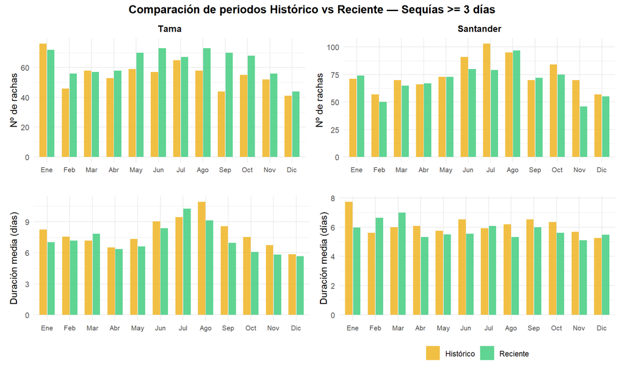

```r
# Función para comparar número y duración media de rachas entre periodos según filtro de duración
comparar_rachas_mes <- function(rachas_tama, rachas_santander, filtro) {

  (plot_rachas_por_mes(rachas_tama, "Tama", mostrar_leyenda = FALSE) |
   plot_rachas_por_mes(rachas_santander, "Santander", mostrar_leyenda = FALSE)) /
  (plot_duracion_media_mes(rachas_tama, mostrar_leyenda = FALSE) |
   plot_duracion_media_mes(rachas_santander)) +
    plot_annotation(
      title = paste("Comparación de periodos Histórico vs Reciente — Sequías >=", filtro, "días"),
      theme = theme(plot.title = element_text(hjust = 0.5, face = "bold"))
    )
}

# Aplicación para distintos filtros de duración
comparar_rachas_mes(rachas_secas_tama_3dias, rachas_secas_santander_3dias, 3)
```

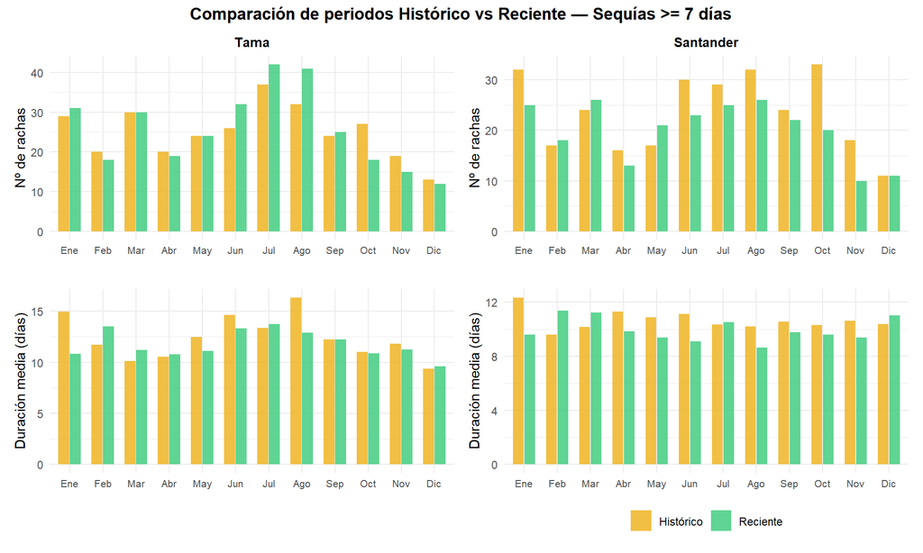

```r
comparar_rachas_mes(rachas_secas_tama_7dias, rachas_secas_santander_7dias, 7)
```

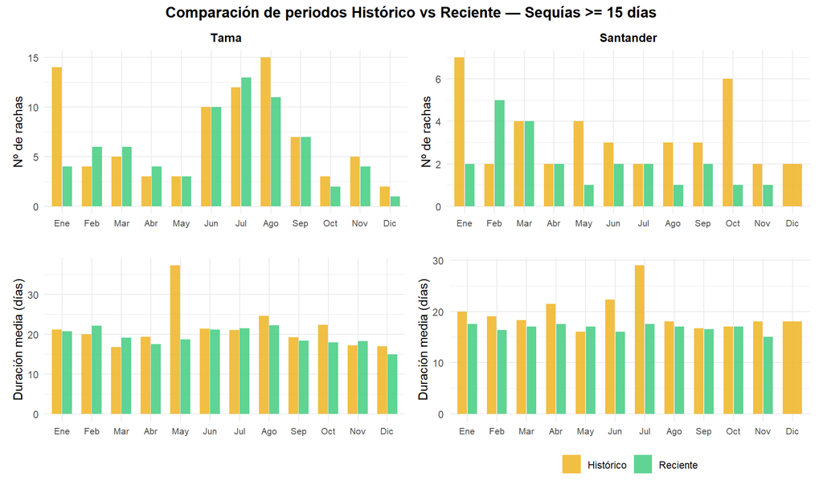

```r
comparar_rachas_mes(rachas_secas_tama_15dias, rachas_secas_santander_15dias, 15)
```

# Sección 6 - Test de Mann-Kendall, pendiente de Sen y test de Pettitt

## 6.1 - Estadísticas de las series anuales principales

`test_mann_kendall()` centraliza todos los análisis de tendencia del documento y es idéntica a la usada en los bloques de temperatura y nivel del mar del TFM, garantizando coherencia metodológica en los tres análisis. Integra en una única llamada cuatro análisis:

1. **Detección de autocorrelación**: calcula el ACF en el lag 1 y lo compara con el intervalo de confianza al 95% (1.96/√n), umbral que depende del tamaño muestral de cada serie concreta.
2. **Selección automática del método**: si `|acf_lag1| <= 1.96/√n` aplica el test estándar (`mk.test`); si lo supera aplica TFPW (`tfpwmk`), que elimina la tendencia lineal antes del blanqueo para evitar inflar el estadístico.
3. **Estimador de Sen**: calcula la pendiente mediana de Theil-Sen con IC al 95% siempre sobre la serie original, antes de cualquier transformación.
4. **Test de Pettitt**: detecta el año de cambio más probable sin asumir normalidad, traduciendo el índice K al año mediante un join con el dataframe de entrada.

Devuelve un tibble de una fila con todos los estadísticos y sus niveles de significancia codificados (** $p$<0.01, * $p$<0.05, · $p$<0.10).

```r
# Aplica Mann-Kendall (estándar o TFPW según autocorrelación), pendiente de Sen y test de Pettitt
test_mann_kendall <- function(df, variable, serie_label = "", metodo = "auto") {
  serie <- df %>%
    arrange(across(any_of(c("anio", "inicio_anio")))) %>%
    pull({{ variable }}) %>%
    na.omit()

  # Selección automática del método según la autocorrelación de orden 1
  n <- length(serie)
  acf_lag1 <- acf(serie, lag.max = 1, plot = FALSE)$acf[2]
  limite_acf <- 1.96 / sqrt(n)
  metodo_usado <- if (metodo == "auto") ifelse(abs(acf_lag1) > limite_acf, "tfpw", "estandar") else metodo

  if (metodo_usado == "estandar") {
    mk <- mk.test(serie)
    tau <- unname(mk$estimates["tau"])
    p_valor <- mk$p.value
  } else {
    mk <- tfpwmk(serie)
    tau <- unname(mk[grep("Tau", names(mk), ignore.case = TRUE)])
    p_valor <- unname(mk[grep("p.value|P.value", names(mk), ignore.case = TRUE)])
  }

  sen <- sens.slope(serie)
  pt <- pettitt.test(serie)

  # Año asociado al cambio detectado por Pettitt
  k_anio <- df %>%
    arrange(across(any_of(c("anio", "inicio_anio")))) %>%
    filter(!is.na({{ variable }})) %>%
    slice(as.integer(pt$estimate[1])) %>%
    pull(any_of(c("anio", "inicio_anio")))

  tibble(
    serie = serie_label, metodo = metodo_usado, acf_lag1 = round(acf_lag1, 3),
    tau = round(tau, 4), p_valor_mk = round(p_valor, 4),
    sen_slope = round(sen$estimates, 4), sen_inf = round(sen$conf.int[1], 4),
    sen_sup = round(sen$conf.int[2], 4),
    interpretacion = case_when(
      p_valor < 0.05 & sen_slope > 0 ~ "Creciente", p_valor < 0.05 & sen_slope < 0 ~ "Decreciente",
      TRUE ~ "Sin tendencia clara"
    ),
    signif_mk = case_when(p_valor < 0.01 ~ "**", p_valor < 0.05 ~ "*", p_valor < 0.10 ~ ".", TRUE ~ ""),
    K_anio = if (length(k_anio)) as.integer(k_anio) else NA_integer_,
    p_valor_pt = round(pt$p.value, 4),
    signif_pt = case_when(pt$p.value < 0.01 ~ "**", pt$p.value < 0.05 ~ "*", pt$p.value < 0.10 ~ ".", TRUE ~ "")
  )
}
```

```r
# Aplicar los tests a cada combinación de estación y variable
tabla_mk_prec <- bind_rows(
  test_mann_kendall(intensidad_tama, total_prec, "Tama - Precipitación total anual"),
  test_mann_kendall(intensidad_santander, total_prec, "Santander - Precipitación total anual"),
  test_mann_kendall(intensidad_tama, intensidad_media, "Tama - Intensidad media"  ),
  test_mann_kendall(intensidad_santander, intensidad_media, "Santander - Intensidad media"),
  test_mann_kendall(intensidad_tama, dias_lluvia, "Tama - Días de lluvia"),
  test_mann_kendall(intensidad_santander, dias_lluvia, "Santander - Días de lluvia")
)

# Mostrar resultados de tendencia y cambios detectados
tabla_mk_prec %>%
  knitr::kable(
    col.names = c("Serie", "Método", "ACF", "Tau", "p-valor", "Pendiente", "IC inf.", "IC sup.",
                  "Interpretación", "Signif.", "Año cambio", "p-valor", "Signif."),
    digits = c(NA, NA, 3, 4, 4, 4, 4, 4, NA, NA, 0, 4, NA),
    caption = "Resultados de tendencia (Mann-Kendall y Sen) y cambios (Pettitt). Significancia: ** p<0,01; * p<0,05; . p<0,10."
  ) %>%
  add_header_above(c(" " = 3, "Mann-Kendall" = 3, "Pendiente de Sen" = 4, "Pettitt" = 3)) %>%
  kableExtra::kable_styling(
    bootstrap_options = c("striped", "hover", "condensed"),
    full_width = FALSE, position = "center"
  )
```

Resultados de tendencia (Mann-Kendall y Sen) y cambios (Pettitt). Significancia: ** p<0,01; * p<0,05; . p<0,10.

Mann-Kendall

Pendiente de Sen

Pettitt

Serie

Método

ACF

Tau

p-valor

Pendiente

IC inf.

IC sup.

Interpretación

Signif.

Año cambio

p-valor

Signif.

Tama - Precipitación total anual

estandar

0.132

-0.0493

0.6073

-0.6885

-4.7462

2.6123

Sin tendencia clara

1979

0.2209

Santander - Precipitación total anual

tfpw

0.347

-0.2309

0.0076

-5.2209

-8.8071

-1.7132

Decreciente

1974

0.0012

Tama - Intensidad media

estandar

0.093

-0.2642

0.0054

-0.0310

-0.0556

-0.0090

Decreciente

1984

0.0230

Santander - Intensidad media

tfpw

0.586

-0.3978

0.0000

-0.0465

-0.0647

-0.0268

Decreciente

1980

0.0000

Tama - Días de lluvia

estandar

0.250

0.2623

0.0061

0.3515

0.1000

0.6316

Creciente

2007

0.0103

Santander - Días de lluvia

estandar

0.217

0.1505

0.0829

0.1579

0.0000

0.3333

Sin tendencia clara

.

1993

0.2077

## 6.2 - Puntos de cambio robustos

Para verificar que los puntos de cambio detectados no son artefactos de los años con datos incompletos, `pettitt_robusto()` repite el test de Pettitt excluyendo previamente todos los años con `anio_valido == FALSE`. Devuelve el año de cambio revisado (`K_anio_rob`), su p-valor y significancia. Se aplica a las seis series mediante una lista iterada con `lapply()`.

```r
# Función para aplicar Pettitt excluyendo años con cobertura insuficiente
pettitt_robusto <- function(df, variable, serie_label = "") {

  anio_col <- ifelse("anio" %in% names(df), "anio", "inicio_anio")

  df <- df %>%
    filter(anio_valido, !is.na(.data[[variable]])) %>%
    arrange(.data[[anio_col]])

  pt <- pettitt.test(df[[variable]])
  k <- as.integer(pt$estimate[1])

  tibble(
    serie = serie_label,
    n_validos = nrow(df),
    K_anio_rob = ifelse(k <= nrow(df), df[[anio_col]][k], NA),
    p_valor_rob = round(pt$p.value, 4),
    signif_rob = case_when(pt$p.value < .01 ~ "**", pt$p.value < .05 ~ "*", pt$p.value < .10 ~ ".", TRUE ~ "")
  )
}
```

El resultado se une a `tabla_mk_prec` mediante `left_join` y construye `tabla_mk_prec_robusta`, que añade la columna `cambio_anio` (`TRUE` si el año de cambio se desplazó al excluir años inválidos). La tabla comparativa con `add_header_above` permite identificar de un vistazo qué puntos de cambio son genuinos y cuáles eran parcialmente artefactos.

```r
# Calcular puntos de cambio robustos para todas las series
series_rob <- list(
  list(intensidad_tama, "total_prec", "Tama - Precipitación total anual"),
  list(intensidad_santander, "total_prec", "Santander - Precipitación total anual"),
  list(intensidad_tama, "intensidad_media", "Tama - Intensidad media"),
  list(intensidad_santander, "intensidad_media", "Santander - Intensidad media"),
  list(intensidad_tama, "dias_lluvia", "Tama - Días de lluvia"),
  list(intensidad_santander, "dias_lluvia", "Santander - Días de lluvia")
)

tabla_rob <- bind_rows(lapply(series_rob, \(x) pettitt_robusto(x[[1]], x[[2]], x[[3]])))

# Comparar los resultados del test de Pettitt original y robusto
tabla_mk_prec_robusta <- tabla_mk_prec %>%
  left_join(
    tabla_rob %>% select(serie, K_anio_rob, p_valor_rob, signif_rob),
    by = "serie"
  ) %>%
  mutate(K_anio_original = K_anio, K_anio = K_anio_rob, cambio_anio = K_anio_original != K_anio_rob)

tabla_mk_prec_robusta %>%
  select(serie, K_anio_original, p_valor_pt, signif_pt, K_anio_rob, p_valor_rob, signif_rob, cambio_anio
  ) %>%
  knitr::kable(
    col.names = c("Serie", "Año cambio (original)", "p-valor", "Sig.", "Año cambio (robusto)", "p-valor", "Sig.", "¿Cambió?"),
    digits = c(NA, 0, 4, NA, 0, 4, NA, NA),
    caption = "Comparación entre puntos de cambio originales y robustos tras excluir años con datos incompletos."
  ) %>%
  add_header_above(c(" " = 1, "Pettitt original" = 3, "Pettitt robusto" = 3, " " = 1)) %>%
  kableExtra::kable_styling(
    bootstrap_options = c("striped", "hover", "condensed"),
    full_width = FALSE, position = "center"
  )
```

Comparación entre puntos de cambio originales y robustos tras excluir años con datos incompletos.

Pettitt original

Pettitt robusto

Serie

Año cambio (original)

p-valor

Sig.

Año cambio (robusto)

p-valor

Sig.

¿Cambió?

Tama - Precipitación total anual

1979

0.2209

1979

0.2499

FALSE

Santander - Precipitación total anual

1974

0.0012

1980

0.0000

TRUE

Tama - Intensidad media

1984

0.0230

1984

0.0197

FALSE

Santander - Intensidad media

1980

0.0000

1980

0.0000

FALSE

Tama - Días de lluvia

2007

0.0103

1995

0.0006

TRUE

Santander - Días de lluvia

1993

0.2077

2007

0.3894

TRUE

# Sección 7 - Análisis de sensibilidad al excluir los meses primaverales

## 7.1 - Integración de tendencias y puntos de cambio en los gráficos

`add_mk_layers()` enriquece cualquier gráfico de serie temporal base con dos capas analíticas: la línea de Sen (recta anclada en la mediana de los años y la mediana de los valores, extendida de extremo a extremo) y la línea vertical de Pettitt (solo si `p_valor_pt` < 0.05). Busca los estadísticos en `tabla_mk` mediante `serie_label`, lo que permite aplicarla a cualquier serie con una única llamada.

La función `aplicar_mk()` actúa como envoltura que fija tabla_mk_prec_robusta como tabla de referencia, y se aplica en batch a las seis series almacenadas en la lista `graficas` mediante `lapply()` y `list2env()`. El panel 3×2 final muestra las seis series con sus tendencias y puntos de cambio integrados directamente sobre los gráficos de barras.

```r
add_mk_layers <- function(p, df, variable, tabla_mk, serie_label, color_sen = "red", color_pt = "darkred") {

  # Buscar resultados del test para la serie seleccionada
  mk <- tabla_mk %>% filter(serie == serie_label)

  if (!nrow(mk)) return(p)

  # Preparar serie y ordenar cronológicamente
  anio_col <- ifelse("anio" %in% names(df), "anio", "inicio_anio")

  df <- df %>%
    arrange(.data[[anio_col]]) %>%
    filter(!is.na(.data[[variable]]))

  anios <- df[[anio_col]]
  vals <- df[[variable]]

  # Añadir línea de tendencia de Sen
  p <- p +
    geom_line(
      data = tibble(x = range(anios), y = median(vals) + mk$sen_slope * (x - median(anios))),
      aes(x, y), inherit.aes = FALSE, color = color_sen, linewidth = 1)

  # Añadir punto de cambio de Pettitt si es significativo
  if (!is.na(mk$K_anio) && mk$p_valor_pt < 0.05) {
    p <- p +
      geom_vline(xintercept = mk$K_anio, color = color_pt, linetype = "dotdash", linewidth = 0.9)
  }

  return(p)
}
```

```r
# Función auxiliar para añadir la tendencia de Sen y el cambio de Pettitt
aplicar_mk <- function(g, df, var, serie) {
  add_mk_layers(g, df, var, tabla_mk_prec_robusta, serie)
}

graficas <- list(
  precipitacion_total_tama = list(plot_precipitacion_total(intensidad_tama, "Tama"), intensidad_tama, "total_prec", "Tama - Precipitación total anual"),
  precipitacion_total_santander = list(plot_precipitacion_total(intensidad_santander, "Santander"), intensidad_santander, "total_prec", "Santander - Precipitación total anual"),
  dias_lluvia_tama = list(plot_dias_lluvia(intensidad_tama, "Tama"), intensidad_tama, "dias_lluvia", "Tama - Días de lluvia"),
  dias_lluvia_santander = list(plot_dias_lluvia(intensidad_santander, "Santander"), intensidad_santander, "dias_lluvia", "Santander - Días de lluvia"),
  intensidad_media_tama = list(plot_intensidad_media(intensidad_tama, "Tama"), intensidad_tama, "intensidad_media", "Tama - Intensidad media"),
  intensidad_media_santander = list(plot_intensidad_media(intensidad_santander, "Santander"), intensidad_santander, "intensidad_media", "Santander - Intensidad media")
)

list2env(lapply(graficas, \(x) aplicar_mk(x[[1]], x[[2]], x[[3]], x[[4]])),
         envir = .GlobalEnv)
```

```
## <environment: R_GlobalEnv>
```

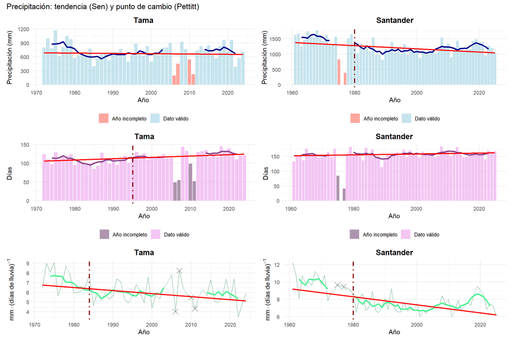

```r
# Panel comparativo
(precipitacion_total_tama | precipitacion_total_santander) /
(dias_lluvia_tama | dias_lluvia_santander) /
(intensidad_media_tama | intensidad_media_santander) +
  plot_annotation(title = "Precipitación: tendencia (Sen) y punto de cambio (Pettitt)")
```

## 7.2 - Exclusión de meses de primavera (abril y mayo)

Para cuantificar la contribución de los meses de primavera a las tendencias detectadas, `calcular_metricas_sin_meses()` recalcula los tres indicadores anuales (precipitación total, días de lluvia e intensidad media) excluyendo los meses indicados en meses_excluir antes de agregar por año. Se generan tres versiones para cada estación: serie completa, sin abril (mes 4) y sin abril y mayo (meses 4 y 5).

```r
# Métricas anuales con opción de excluir meses
calcular_metricas_sin_meses <- function(df, calidad, meses_excluir = c()) {

  df %>%
    filter(!mes %in% meses_excluir) %>%
    group_by(anio) %>%
    summarise(total_prec  = sum(prec, na.rm = TRUE),
              dias_lluvia = sum(lluvia == TRUE, na.rm = TRUE),
              intensidad_media = ifelse(dias_lluvia > 0,
                                        total_prec / dias_lluvia, NA),
              dias_con_dato_anioIncompleto = sum(!is.na(prec)),
              .groups = "drop"
              ) %>%
    left_join(calidad, by = "anio")
}

# Sin abril
metricas_tama_sinAbr <- calcular_metricas_sin_meses(datos_tama_sin_NA, calidad_tama, 4)
metricas_santander_sinAbr <- calcular_metricas_sin_meses(datos_santander_limpios, calidad_santander, 4)

# Sin abril y mayo
metricas_tama_sinAbrMay <- calcular_metricas_sin_meses(datos_tama_sin_NA, calidad_tama, c(4, 5))
metricas_santander_sinAbrMay <- calcular_metricas_sin_meses(datos_santander_limpios, calidad_santander, c(4, 5))
```

Aplicando `test_mann_kendall()` a las 18 series resultantes se construye `tabla_sensibilidad`, que compara las pendientes de Sen y los p-valores entre escenarios. La tabla presentada con `kableExtra` organiza los resultados agrupados por variable, estación y escenario para facilitar la comparación directa.

```r
# Comparación de tendencias: completa vs sensibilidad (abril / abril-mayo)
tabla_sensibilidad <- bind_rows(

  # Serie completa
  test_mann_kendall(intensidad_tama, total_prec, "Tama - Prec. total (completa)"),
  test_mann_kendall(intensidad_santander, total_prec, "Santander - Prec. total (completa)"),
  test_mann_kendall(intensidad_tama, intensidad_media, "Tama - Intensidad (completa)"),
  test_mann_kendall(intensidad_santander, intensidad_media, "Santander - Intensidad (completa)"),
  test_mann_kendall(intensidad_tama, dias_lluvia, "Tama - Días lluvia (completa)"),
  test_mann_kendall(intensidad_santander, dias_lluvia,"Santander - Días lluvia (completa)"),

  # Sin abril
  test_mann_kendall(metricas_tama_sinAbr, total_prec, "Tama - Prec. total (sin abril)"),
  test_mann_kendall(metricas_santander_sinAbr, total_prec, "Santander - Prec. total (sin abril)"),
  test_mann_kendall(metricas_tama_sinAbr, intensidad_media, "Tama - Intensidad (sin abril)"),
  test_mann_kendall(metricas_santander_sinAbr, intensidad_media, "Santander - Intensidad (sin abril)"),
  test_mann_kendall(metricas_tama_sinAbr, dias_lluvia, "Tama - Días lluvia (sin abril)"),
  test_mann_kendall(metricas_santander_sinAbr, dias_lluvia, "Santander - Días lluvia (sin abril)"),

  # Sin abril y mayo
  test_mann_kendall(metricas_tama_sinAbrMay, total_prec, "Tama - Prec. total (sin abr-may)"),
  test_mann_kendall(metricas_santander_sinAbrMay, total_prec, "Santander - Prec. total (sin abr-may)"),
  test_mann_kendall(metricas_tama_sinAbrMay, intensidad_media, "Tama - Intensidad (sin abr-may)"),
  test_mann_kendall(metricas_santander_sinAbrMay, intensidad_media, "Santander - Intensidad (sin abr-may)"),
  test_mann_kendall(metricas_tama_sinAbrMay, dias_lluvia, "Tama - Días lluvia (sin abr-may)"),
  test_mann_kendall(metricas_santander_sinAbrMay, dias_lluvia, "Santander - Días lluvia (sin abr-may)")
)
```

```r
tabla_sensibilidad %>%
  mutate(
    escenario = case_when(
      grepl("completa", serie) ~ "Serie completa",
      grepl("sin abril\\)", serie) ~ "Sin abril",
      TRUE ~ "Sin abril-mayo"
    ),
    serie_base = ifelse(grepl("Tama", serie), "Tama", "Santander"),
    variable = case_when(
      grepl("Prec", serie) ~ "Precipitación total",
      grepl("Intensidad", serie) ~ "Intensidad media",
      TRUE ~ "Días de lluvia"
    ),
    escenario = factor(escenario,
      levels = c("Serie completa", "Sin abril", "Sin abril-mayo")
    )
  ) %>%
  arrange(variable, serie_base, escenario) %>%
  select(
    serie_base, variable, escenario, metodo,
    tau, p_valor_mk, sen_slope, sen_inf, sen_sup,
    interpretacion, signif_mk
  ) %>%
  knitr::kable(
    col.names = c("Estación", "Variable", "Escenario", "Método", "Tau", "p-valor MK", "Pendiente Sen",
                  "IC 95% inf.", "IC 95% sup.", "Tendencia", "Sig."),
    digits = c(NA, NA, NA, NA, 4, 4, 4, 3, 3, NA, NA),
    caption = "Sensibilidad de las tendencias detectadas frente a la eliminación de abril y abril-mayo."
  ) %>%
  kableExtra::kable_styling(
    bootstrap_options = c("striped", "hover", "condensed"),
    full_width = FALSE, position = "center"
  )
```

Sensibilidad de las tendencias detectadas frente a la eliminación de abril y abril-mayo.

Estación

Variable

Escenario

Método

Tau

p-valor MK

Pendiente Sen

IC 95% inf.

IC 95% sup.

Tendencia

Sig.

Santander

Días de lluvia

Serie completa

estandar

0.1505

0.0829

0.1579

0.000

0.333

Sin tendencia clara

.

Santander

Días de lluvia

Sin abril

tfpw

0.1459

0.0921

0.1875

0.000

0.389

Sin tendencia clara

.

Santander

Días de lluvia

Sin abril-mayo

tfpw

0.1685

0.0517

0.1940

0.040

0.342

Sin tendencia clara

.

Tama

Días de lluvia

Serie completa

estandar

0.2623

0.0061

0.3515

0.100

0.632

Creciente

Tama

Días de lluvia

Sin abril

estandar

0.2504

0.0088

0.3717

0.100

0.613

Creciente

Tama

Días de lluvia

Sin abril-mayo

tfpw

0.3167

0.0009

0.4167

0.162

0.667

Creciente

Santander

Intensidad media

Serie completa

tfpw

-0.3978

0.0000

-0.0465

-0.065

-0.027

Decreciente

Santander

Intensidad media

Sin abril

tfpw

-0.3344

0.0001

-0.0430

-0.064

-0.022

Decreciente

Santander

Intensidad media

Sin abril-mayo

tfpw

-0.2913

0.0008

-0.0427

-0.065

-0.018

Decreciente

Tama

Intensidad media

Serie completa

estandar

-0.2642

0.0054

-0.0310

-0.056

-0.009

Decreciente

Tama

Intensidad media

Sin abril

estandar

-0.1814

0.0561

-0.0217

-0.054

0.001

Sin tendencia clara

.

Tama

Intensidad media

Sin abril-mayo

estandar

-0.1335

0.1604

-0.0204

-0.051

0.006

Sin tendencia clara

Santander

Precipitación total

Serie completa

tfpw

-0.2309

0.0076

-5.2209

-8.807

-1.713

Decreciente

Santander

Precipitación total

Sin abril

tfpw

-0.1715

0.0476

-3.9430

-7.453

-0.370

Decreciente

Santander

Precipitación total

Sin abril-mayo

tfpw

-0.1173

0.1763

-3.1423

-6.476

0.327

Sin tendencia clara

Tama

Precipitación total

Serie completa

estandar

-0.0493

0.6073

-0.6885

-4.746

2.612

Sin tendencia clara

Tama

Precipitación total

Sin abril

estandar

-0.0044

0.9694

-0.1184

-4.108

3.702

Sin tendencia clara

Tama

Precipitación total

Sin abril-mayo

estandar

0.0392

0.6843

0.7855

-3.350

4.029

Sin tendencia clara

La función auxiliar `interna make_sen_df()` calcula los dos puntos extremos de cada recta de Sen; `get_sen()` busca la pendiente en `tabla_mk` por etiqueta de serie.

```r
plot_sensibilidad_sen <- function(
  df_completa, df_sinAbr, df_sinAbrMay,
  variable, estacion, tabla_mk,
  color_anio_valido="lightblue", color_anio_invalido="salmon",
  color_linea="grey40", color_media_movil="darkblue",
  color_sen_completa="firebrick", color_sen_sinAbr="tan1", color_sen_sinAbrMay="chartreuse4",
  mostrar_barras=TRUE, mostrar_linea=FALSE, mostrar_media_movil=TRUE,
  mostrar_leyenda_barras=TRUE, mostrar_leyenda_sen=TRUE,
  mostrar_unidad_y=TRUE, mostrar_titulo=TRUE, mostrar_subtitulo=TRUE, mostrar_titulo_y=TRUE,
  mostrar_titulo_x=TRUE, mostrar_cruces_invalidos=FALSE, window=5
) {

  # ─────────────────────────────────────────────────────────────
  # 1. Columna de año (robusto a diferentes nombres)
  # ─────────────────────────────────────────────────────────────
  anio_col <- if ("anio" %in% names(df_completa)) "anio" else "inicio_anio"

  # ─────────────────────────────────────────────────────────────
  # 2. Metadatos de la variable (nombre + unidad)
  # ─────────────────────────────────────────────────────────────
  info <- switch(variable,
                 total_prec=list("Precipitación total","mm"),
                 dias_lluvia=list("Días con lluvia","días"),
                 intensidad_media=list("Intensidad media","mm/días de lluvia"),
                 list(variable,"")
  )

  nombre_variable <- info[[1]]
  unidad_variable <- info[[2]]

  # Etiquetas de ejes según flags
  ylab <- if (mostrar_titulo_y)
    if (mostrar_unidad_y)
      paste0(nombre_variable," (",unidad_variable,")")
    else nombre_variable
  else NULL

  xlabel <- if (mostrar_titulo_x) "Año" else NULL

  # ─────────────────────────────────────────────────────────────
  # 3. Etiquetas de leyenda (series Sen)
  # ─────────────────────────────────────────────────────────────
  lab <- c("Serie completa","Sin abril","Sin abril y mayo")

  nombre_corto <- switch(variable, total_prec="Prec. total", dias_lluvia="Días lluvia",
                         intensidad_media="Intensidad", variable)

  # ─────────────────────────────────────────────────────────────
  # 4. Extracción de pendientes Sen desde tabla
  # ─────────────────────────────────────────────────────────────
  get_sen <- function(suf){
    etiqueta <- paste0(estacion," - ",nombre_corto," (",suf,")")
    res <- tabla_mk %>% filter(serie==etiqueta) %>% slice(1) %>% pull(sen_slope)

    if (length(res)==0) {
      warning(paste("No encontrado:",etiqueta))
      return(NA_real_)
    }

    res
  }

  slopes <- c(get_sen("completa"), get_sen("sin abril"), get_sen("sin abr-may"))

  # ─────────────────────────────────────────────────────────────
  # 5. Preparación de datos base
  # ─────────────────────────────────────────────────────────────

  # Asegura existencia de variable de validez del año
  if (!"anio_valido" %in% names(df_completa))
    df_completa$anio_valido <- TRUE

  # Cálculo de media móvil (solo con años válidos)
  df_completa <- df_completa %>%
    arrange(.data[[anio_col]]) %>%
    mutate(media_movil = zoo::rollmean(
      ifelse(anio_valido,.data[[variable]],NA),
      k=window, fill=NA, align="center"
    ))

  # ─────────────────────────────────────────────────────────────
  # 6. Construcción de líneas Sen (tendencias)
  # ─────────────────────────────────────────────────────────────
  make_sen_df <- function(df,slope,label){

    # Si no hay pendiente, no se dibuja línea
    if (is.na(slope))
      return(tibble(x=numeric(),ysen=numeric(),caso=character()))

    vals  <- df[[variable]]
    anios <- df[[anio_col]]

    med_a <- median(anios,na.rm=TRUE)
    med_v <- median(vals,na.rm=TRUE)

    tibble(
      x=c(min(anios),max(anios)),
      ysen=med_v + slope*(c(min(anios),max(anios)) - med_a),
      caso=label
    )
  }

  # Unión de las tres versiones de Sen
  sen_all <- bind_rows(make_sen_df(df_completa, slopes[1], lab[1]),
                       make_sen_df(df_sinAbr, slopes[2], lab[2]),
                       make_sen_df(df_sinAbrMay, slopes[3], lab[3])
                       ) %>%
    mutate(caso=factor(caso,levels=lab))

  # ─────────────────────────────────────────────────────────────
  # 7. Base del gráfico
  # ─────────────────────────────────────────────────────────────
  p <- ggplot(df_completa,aes(x=.data[[anio_col]],y=.data[[variable]]))

  # ─────────────────────────────────────────────────────────────
  # 8. Barras (años válidos vs inválidos)
  # ─────────────────────────────────────────────────────────────
  if (mostrar_barras)
    p <- p +
      geom_col(aes(fill=anio_valido),alpha=.6,width=.8,
               show.legend=mostrar_leyenda_barras) +
      scale_fill_manual(
        values=c("TRUE"=color_anio_valido,"FALSE"=color_anio_invalido),
        labels=c("TRUE"="Dato válido","FALSE"="Año incompleto"),
        name=NULL
      )

  # ─────────────────────────────────────────────────────────────
  # 9. Línea de serie original (opcional)
  # ─────────────────────────────────────────────────────────────
  if (mostrar_linea)
    p <- p +
      geom_line(color=color_linea,linewidth=.6,alpha=.8)

  # ─────────────────────────────────────────────────────────────
  # 10. Cruces de años inválidos (opcional)
  # ─────────────────────────────────────────────────────────────
  if (mostrar_cruces_invalidos)
    p <- p +
      geom_point(data=dplyr::filter(df_completa,!anio_valido),
                 aes(x=.data[[anio_col]],y=.data[[variable]]),
                 color=color_anio_invalido,shape=4,size=2.5,
                 inherit.aes=FALSE)

  # ─────────────────────────────────────────────────────────────
  # 11. Media móvil (suavizado)
  # ─────────────────────────────────────────────────────────────
  if (mostrar_media_movil)
    p <- p +
      geom_line(aes(y=media_movil), color=color_media_movil, linewidth=1.1,na.rm=TRUE,show.legend=FALSE)

  # ─────────────────────────────────────────────────────────────
  # 12. Líneas Sen (tendencias)
  # ─────────────────────────────────────────────────────────────
  p <- p +
    geom_line(data=sen_all, aes(x=x,y=ysen,color=caso,linetype=caso),
              linewidth=.95,inherit.aes=FALSE, show.legend=mostrar_leyenda_sen) +
    scale_color_manual(values=setNames(c(color_sen_completa,color_sen_sinAbr,color_sen_sinAbrMay),lab),
                       name=NULL) +
    scale_linetype_manual(values=setNames(c("solid","dashed","dotdash"),lab), name=NULL)

  # ─────────────────────────────────────────────────────────────
  # 13. Etiquetas + tema
  # ─────────────────────────────────────────────────────────────
  p <- p +
    labs(title=if(mostrar_titulo) nombre_variable else NULL,
         subtitle=if(mostrar_subtitulo) estacion else NULL, x=xlabel,y=ylab) +
    theme_minimal() +
    theme(
      plot.title=element_text(hjust=.5,face="bold",size=11),
      plot.subtitle=element_text(hjust=.5,size=9,color="grey40",face="italic"),
      legend.position="bottom", legend.box="vertical",
      legend.spacing.y=unit(.2,"cm"), legend.text=element_text(size=8),
      axis.title=element_text(size=9), axis.text=element_text(size=8),
      panel.grid.minor=element_blank()
    )

  # ─────────────────────────────────────────────────────────────
  # 14. Control de leyendas
  # ─────────────────────────────────────────────────────────────
  if (!mostrar_leyenda_barras) p <- p + guides(fill="none")
  if (!mostrar_leyenda_sen) p <- p + guides(color="none",linetype="none")

  p
}
```